# Reconstructing Two-Arm Individual Patient Data from Kaplan–Meier Curves

A practical, annotated R tutorial

Author

Kwadwo Darko

Published

September 10, 2026

## 1 Purpose

This tutorial reconstructs approximate individual patient data (IPD) from **two digitized Kaplan–Meier (KM) curves**, combines the reconstructed records into a two-arm dataset, checks the reconstruction, and compares the arms with:

- a log-rank test;
- a Cox proportional hazards model and hazard ratio (HR);
- median overall survival (OS) for each arm; and
- mortality event rates for each arm.

The final KM figure displays the HR with its 95% confidence interval, log-rank p-value, median OS, and event rates. Numerical results are shown to two decimal places.

## 2 Packages

The analysis uses a deliberately small package set. Install each package once, if needed, and then load it for the current R session.

```r
required_packages <- c(
  "dplyr",
  "purrr",
  "ggplot2",
  "survival",
  "survminer",
  "broom",
  "knitr",
  "gtsummary"
)

packages_to_install <- setdiff(
  required_packages,
  rownames(installed.packages())
)

if (length(packages_to_install) > 0) {
  install.packages(packages_to_install)
}

invisible(
  lapply(required_packages, library, character.only = TRUE)
)
```

The same validation function is used at the end of both scenarios. It checks each arm’s median OS and the hazard ratio in the stated Arm 2-versus-Arm 1 direction.

```r
run_reconstruction_sanity_checks <- function(
    reconstructed_hr,
    reported_hr,
    reconstructed_medians,
    reported_medians,
    arm_labels,
    median_tolerance_months = 0.20,
    log_hr_tolerance = 0.10) {

  if (length(reconstructed_hr) != 1L || !is.finite(reconstructed_hr) ||
      reconstructed_hr <= 0 || length(reported_hr) != 1L ||
      !is.finite(reported_hr) || reported_hr <= 0) {
    stop("Reported and reconstructed HRs must each be one positive number.")
  }

  if (length(reconstructed_medians) != 2L ||
      length(reported_medians) != 2L || length(arm_labels) != 2L) {
    stop("Supply exactly two reconstructed medians, reported medians, and arm labels.")
  }

  median_difference <- abs(reconstructed_medians - reported_medians)
  median_pass <- is.finite(median_difference) &
    median_difference <= median_tolerance_months + sqrt(.Machine$double.eps)

  log_hr_difference <- abs(log(reported_hr / reconstructed_hr))
  hr_pass <- is.finite(log_hr_difference) &&
    log_hr_difference <= log_hr_tolerance + sqrt(.Machine$double.eps)

  results <- data.frame(
    check = c(
      paste0("Median OS: ", arm_labels[1]),
      paste0("Median OS: ", arm_labels[2]),
      paste0("HR: ", arm_labels[2], " vs ", arm_labels[1])
    ),
    reported = sprintf("%.2f", c(reported_medians, reported_hr)),
    reconstructed = sprintf("%.2f", c(reconstructed_medians, reconstructed_hr)),
    comparison = c(
      sprintf("absolute difference = %.2f months", median_difference),
      sprintf("absolute log ratio = %.3f", log_hr_difference)
    ),
    acceptance_rule = c(
      rep(sprintf("difference <= %.2f months", median_tolerance_months), 2L),
      sprintf("absolute log ratio <= %.2f", log_hr_tolerance)
    ),
    result = ifelse(c(median_pass, hr_pass), "PASS", "FAIL"),
    check.names = FALSE
  )

  display_data <- data.frame(
    check = results$check,
    reported = c(reported_medians, reported_hr),
    reconstructed = c(reconstructed_medians, reconstructed_hr),
    diagnostic = c(median_difference, log_hr_difference),
    acceptance_limit = c(
      median_tolerance_months,
      median_tolerance_months,
      log_hr_tolerance
    ),
    passed = as.integer(c(median_pass, hr_pass)),
    check.names = FALSE
  )

  failed_checks <- results$check[results$result == "FAIL"]
  if (length(failed_checks) == 0L) {
    cat("\nOVERALL RESULT: PASS - all median OS and HR sanity checks passed.\n")
  } else {
    cat("\nOVERALL RESULT: FAIL - the following check(s) did not pass:\n")
    cat(paste0("- ", failed_checks, collapse = "\n"), "\n")
  }

  invisible(
    list(
      results = results,
      display_data = display_data,
      all_pass = length(failed_checks) == 0L
    )
  )
}

display_sanity_check_table <- function(checks, table_title) {
  overall_result <- ifelse(checks$all_pass, "PASS", "FAIL")
  full_title <- paste0(table_title, " - Overall result: ", overall_result)

  table_data <- checks$display_data |>
    dplyr::mutate(
      check = factor(check, levels = check)
    )

  formatted_table <- table_data |>
    gtsummary::tbl_summary(
      by = check,
      include = -check,
      type = dplyr::everything() ~ "continuous",
      statistic = dplyr::everything() ~ "{mean}",
      digits = list(
        reported ~ 2,
        reconstructed ~ 2,
        diagnostic ~ 3,
        acceptance_limit ~ 2,
        passed ~ 0
      ),
      label = list(
        reported ~ "Reported",
        reconstructed ~ "Reconstructed",
        diagnostic ~ "Absolute difference / log ratio",
        acceptance_limit ~ "Acceptance limit (<=)",
        passed ~ "Result"
      ),
      missing = "no"
    ) |>
    gtsummary::modify_header(
      gtsummary::all_stat_cols() ~ "**{level}**"
    ) |>
    gtsummary::modify_footnote_header(
      footnote = NA_character_,
      columns = gtsummary::all_stat_cols()
    ) |>
    gtsummary::modify_footnote_header(
      footnote = paste0(
        "Cross-check and confirm that the original and reconstructed median ",
        "time to survival have been reported in the same unit of months."
      ),
      columns = c(stat_1, stat_2),
      replace = TRUE
    ) |>
    gtsummary::modify_table_body(
      ~ .x |>
        dplyr::mutate(
          dplyr::across(
            dplyr::starts_with("stat_"),
            ~ ifelse(
              variable == "passed",
              ifelse(.x == "1", "PASS", "FAIL"),
              .x
            )
          )
        )
    ) |>
    gtsummary::bold_labels() |>
    gtsummary::modify_caption(paste0("**", full_title, "**"))

  # Quarto renders the gtsummary object as a publication-ready table.
  if (knitr::is_html_output()) {
    return(formatted_table)
  }

  # Printing a gtsummary table interactively opens its HTML output in the
  # RStudio Viewer without calling the native spreadsheet Data Viewer.
  if (interactive()) {
    tryCatch(
      print(formatted_table),
      error = function(error_condition) {
        message("The HTML Viewer could not be opened; using the console table.")
      }
    )
  }

  # Always retain a console fallback and keep the underlying data accessible.
  print(checks$results, row.names = FALSE)
  invisible(checks$results)
}
```

## 3 Reconstruction workflows

Choose the tab that matches the information reported with the published Kaplan–Meier figure. Both workflows use two arms and finish with the same survival summaries.

**Scenario 1 — No numbers-at-risk table**

Download the complete Scenario 1 R script

**Show the complete Scenario 1 script** — use the copy button in the upper-right corner of the code block**

```r
# Scenario 1: no numbers-at-risk table
# Generated from the Quarto tutorial. Change only values in USER INPUTS.

# ---- packages ----

required_packages <- c(
  "dplyr",
  "purrr",
  "ggplot2",
  "survival",
  "survminer",
  "broom",
  "knitr",
  "gtsummary"
)

packages_to_install <- setdiff(
  required_packages,
  rownames(installed.packages())
)

if (length(packages_to_install) > 0) {
  install.packages(packages_to_install)
}

invisible(
  lapply(required_packages, library, character.only = TRUE)
)

# ---- user-inputs ----

# ====================== USER INPUTS: CHANGE THESE ======================

# STEP 1: Keep TRUE while learning with the dummy data.
# Change this to FALSE when you are ready to use your own two CSV files.
use_demo_data <- TRUE

# STEP 2: Enter the information for Arm 1.
# Arm 1 becomes the reference group in the hazard-ratio calculation.
arm1_file <- "~/Downloads/arm1_digitized_curve.csv" # CHANGE: path to Arm 1 CSV
arm1_N <- 62L                                        # CHANGE: number at risk at time 0
arm1_label <- "Control"                             # CHANGE: arm name from the paper

# Leave as NA_real_ when the CSV time column is already in months/years.
# If the digitized time is scaled from 0 to 1, replace NA_real_ with the
# maximum time shown on the paper's x-axis (for example, 36).
arm1_time_max <- NA_real_                            # USUALLY LEAVE UNCHANGED

# STEP 3: Enter the information for Arm 2.
arm2_file <- "~/Downloads/arm2_digitized_curve.csv" # CHANGE: path to Arm 2 CSV
arm2_N <- 80L                                        # CHANGE: number at risk at time 0
arm2_label <- "Treatment"                           # CHANGE: arm name from the paper
arm2_time_max <- NA_real_                            # USUALLY LEAVE UNCHANGED

# STEP 4: Enter the results reported in the paper for the sanity checks.
# The HR must be Arm 2 versus Arm 1. If the paper gives Arm 1 versus Arm 2,
# enter its reciprocal (1 / the reported HR) instead.
reported_hr_arm2_vs_arm1 <- 0.66       # CHANGE: published HR, Arm 2 vs Arm 1
reported_median_os_arm1 <- 16.75       # CHANGE: published Arm 1 median OS, months
reported_median_os_arm2 <- 22.93       # CHANGE: published Arm 2 median OS, months

# STEP 5: Review the plot settings.
time_unit <- "Months"
x_axis_max <- 36                      # CHANGE to the largest x-axis time to display
x_axis_break_by <- 6                  # CHANGE to the spacing used in the paper (spacing between ticks on the x-axis)
arm_colours <- c("#D55E00", "#0072B2") # OPTIONAL: Arm 1 and Arm 2 colours

# ==================== END OF VALUES TO CHANGE =========================

# ---- demo-data ----

if (use_demo_data) {
  arm1_curve <- data.frame(
    time = c(0, 3, 6, 9, 12, 15, 18, 21, 24, 30, 36),
    survival = c(1.00, 0.94, 0.84, 0.74, 0.64, 0.55, 0.47, 0.39, 0.32, 0.23, 0.16)
  )

  arm2_curve <- data.frame(
    time = c(0, 3, 6, 9, 12, 15, 18, 21, 24, 30, 36),
    survival = c(1.00, 0.97, 0.91, 0.85, 0.78, 0.70, 0.63, 0.56, 0.49, 0.38, 0.29)
  )
}

# ---- clean-km-function ----

clamp01 <- function(x) {
  pmin(pmax(x, 0), 1)
}

clean_km <- function(t_raw, S_raw) {
  if (length(t_raw) != length(S_raw)) {
    stop("Time and survival vectors must have the same length.")
  }

  curve <- data.frame(
    time = as.numeric(t_raw),
    survival = as.numeric(S_raw)
  ) |>
    dplyr::filter(!is.na(time), !is.na(survival)) |>
    dplyr::arrange(time) |>
    # At duplicate times, keep the lowest survival value (the full step drop).
    dplyr::group_by(time) |>
    dplyr::summarise(survival = min(survival), .groups = "drop")

  if (nrow(curve) < 2) {
    stop("The digitized curve must contain at least two valid points.")
  }

  if (curve$time[1] < 0) {
    stop("Time values cannot be negative.")
  }

  if (curve$time[1] > 0) {
    curve <- dplyr::bind_rows(
      data.frame(time = 0, survival = 1),
      curve
    )
  } else {
    curve$survival[1] <- 1
  }

  curve$survival <- clamp01(curve$survival)
  curve$survival <- cummin(curve$survival)
  curve
}

# ---- estimate-events-function ----

events_no_censor <- function(S, N) {
  if (length(S) < 2) {
    stop("At least two survival values are required.")
  }
  if (length(N) != 1 || is.na(N) || N <= 0 || N != as.integer(N)) {
    stop("Baseline N must be one positive integer.")
  }

  n_points <- length(S)
  at_risk <- integer(n_points)
  events <- integer(n_points - 1L)
  at_risk[1] <- as.integer(N)

  for (j in seq_len(n_points - 1L)) {
    if (S[j] <= 0 || at_risk[j] == 0) {
      estimated_events <- at_risk[j]
    } else {
      estimated_events <- round(
        at_risk[j] * (1 - S[j + 1L] / S[j])
      )
    }

    estimated_events <- max(
      0L,
      min(as.integer(estimated_events), at_risk[j])
    )

    events[j] <- estimated_events
    at_risk[j + 1L] <- at_risk[j] - events[j]
  }

  # Reconcile the total with the survival probability at the last point.
  target_survivors <- as.integer(round(N * S[n_points]))
  target_total_events <- as.integer(N - target_survivors)
  event_difference <- target_total_events - sum(events)

  if (event_difference > 0L) {
    for (j in rev(seq_along(events))) {
      available <- N - sum(events)
      add <- min(event_difference, available)
      events[j] <- events[j] + add
      event_difference <- event_difference - add
      if (event_difference == 0L) break
    }
  } else if (event_difference < 0L) {
    events_to_remove <- -event_difference
    for (j in rev(seq_along(events))) {
      remove <- min(events_to_remove, events[j])
      events[j] <- events[j] - remove
      events_to_remove <- events_to_remove - remove
      if (events_to_remove == 0L) break
    }
  }

  events
}

# ---- build-ipd-function ----

build_ipd_uniform <- function(curve, events, N, arm_label) {
  if (length(events) != nrow(curve) - 1L) {
    stop("There must be one event count per curve interval.")
  }

  event_times <- purrr::map2(
    seq_len(nrow(curve) - 1L),
    events,
    function(j, number_events) {
      if (number_events == 0L) return(numeric(0))
```

```r
      seq(
        from = curve$time[j],
        to = curve$time[j + 1L],
        length.out = number_events + 2L
      )[-c(1L, number_events + 2L)]
    }
  ) |>
    unlist(use.names = FALSE)

  number_censored <- N - length(event_times)
  if (number_censored < 0) {
    stop("Estimated events exceed baseline N.")
  }

  data.frame(
    time = c(event_times, rep(max(curve$time), number_censored)),
    status = c(rep(1L, length(event_times)), rep(0L, number_censored)),
    arm = arm_label
  )
}

# ---- reconstruct-arm-function ----

read_digitized_curve <- function(file) {
  first_attempt <- tryCatch(
    read.csv(file, header = FALSE),
    error = function(e) NULL
  )

  if (!is.null(first_attempt) && ncol(first_attempt) >= 2 &&
      all(!is.na(suppressWarnings(as.numeric(first_attempt[[1]]))))) {
    return(first_attempt[, 1:2])
  }

  second_attempt <- read.csv(file, header = TRUE)
  if (ncol(second_attempt) < 2) {
    stop("The digitized file must contain at least two columns.")
  }
  second_attempt[, 1:2]
}

reconstruct_arm <- function(file = NULL,
                            curve_data = NULL,
                            baseline_N,
                            arm_label,
                            time_max = NA_real_) {
  if (is.null(curve_data)) {
    if (is.null(file) || !file.exists(path.expand(file))) {
      stop("Digitized file not found for arm: ", arm_label)
    }
    raw_curve <- read_digitized_curve(path.expand(file))
  } else {
    raw_curve <- curve_data[, 1:2]
  }

  raw_time <- suppressWarnings(as.numeric(raw_curve[[1]]))
  raw_survival <- suppressWarnings(as.numeric(raw_curve[[2]]))

  if (!is.na(time_max)) {
    raw_time <- raw_time * time_max
  }

  cleaned_curve <- clean_km(raw_time, raw_survival)
  estimated_events <- events_no_censor(
    cleaned_curve$survival,
    baseline_N
  )
  reconstructed_ipd <- build_ipd_uniform(
    cleaned_curve,
    estimated_events,
    baseline_N,
    arm_label
  )

  list(
    curve = cleaned_curve,
    interval_events = estimated_events,
    ipd = reconstructed_ipd
  )
}

# ---- reconstruct-two-arms ----

arm1_result <- reconstruct_arm(
  file = if (!use_demo_data) arm1_file else NULL,
  curve_data = if (use_demo_data) arm1_curve else NULL,
  baseline_N = arm1_N,
  arm_label = arm1_label,
  time_max = arm1_time_max
)

arm2_result <- reconstruct_arm(
  file = if (!use_demo_data) arm2_file else NULL,
  curve_data = if (use_demo_data) arm2_curve else NULL,
  baseline_N = arm2_N,
  arm_label = arm2_label,
  time_max = arm2_time_max
)

combined_ipd <- dplyr::bind_rows(
  arm1_result$ipd,
  arm2_result$ipd
) |>
  dplyr::mutate(
    status = as.integer(status),
    arm = factor(arm, levels = c(arm1_label, arm2_label))
  )

head(combined_ipd)

# ---- validation-tests ----

stopifnot(
  nrow(arm1_result$ipd) == arm1_N,
  nrow(arm2_result$ipd) == arm2_N,
  nrow(combined_ipd) == arm1_N + arm2_N,
  all(combined_ipd$status %in% c(0L, 1L)),
  all(is.finite(combined_ipd$time)),
  all(combined_ipd$time >= 0),
  !anyNA(combined_ipd)
)

validation_summary <- combined_ipd |>
  dplyr::group_by(arm) |>
  dplyr::summarise(
    participants = dplyr::n(),
    deaths = sum(status),
    censored = sum(status == 0L),
    event_rate_percent = 100 * mean(status),
    .groups = "drop"
  )

validation_summary |>
  dplyr::mutate(
    event_rate_percent = sprintf("%.2f%%", event_rate_percent)
  )

# ---- arm-diagnostic-function ----

plot_arm_check <- function(result, arm_label, colour) {
  reconstructed_fit <- survival::survfit(
    survival::Surv(time, status) ~ 1,
    data = result$ipd
  )

  reconstructed_curve <- data.frame(
    time = c(0, reconstructed_fit$time),
    survival = c(1, reconstructed_fit$surv),
    source = "Reconstructed IPD"
  )

  ggplot2::ggplot() +
    ggplot2::geom_step(
      data = reconstructed_curve,
      ggplot2::aes(time, survival, colour = source),
      linewidth = 1
    ) +
    ggplot2::geom_point(
      data = result$curve,
      ggplot2::aes(time, survival, shape = "Digitized points"),
      colour = colour,
      size = 2
    ) +
    ggplot2::scale_colour_manual(values = c("Reconstructed IPD" = colour)) +
    ggplot2::scale_shape_manual(values = c("Digitized points" = 16)) +
    ggplot2::scale_y_continuous(
      limits = c(0, 1),
      labels = scales::label_percent(accuracy = 1)
    ) +
    ggplot2::labs(
      title = paste("Reconstruction check:", arm_label),
      x = paste("Time (", time_unit, ")", sep = ""),
      y = "Survival probability",
      colour = NULL,
      shape = NULL
    ) +
    ggplot2::theme_classic(base_size = 12) +
    ggplot2::theme(legend.position = "bottom")
}

# ---- plot-arm-1 ----

plot_arm_check(arm1_result, arm1_label, arm_colours[1])

# ---- plot-arm-2 ----

plot_arm_check(arm2_result, arm2_label, arm_colours[2])

# ---- survival-models ----

survival_object <- survival::Surv(
  time = combined_ipd$time,
  event = combined_ipd$status
)

km_fit <- survival::survfit(
  survival_object ~ arm,
  data = combined_ipd
)

logrank_fit <- survival::survdiff(
  survival_object ~ arm,
  data = combined_ipd
)

logrank_p <- stats::pchisq(
  logrank_fit$chisq,
  df = length(logrank_fit$n) - 1L,
  lower.tail = FALSE
)

cox_fit <- survival::coxph(
  survival_object ~ arm,
  data = combined_ipd
)

cox_result <- broom::tidy(
  cox_fit,
  exponentiate = TRUE,
  conf.int = TRUE
)

hr <- cox_result$estimate[1]
hr_ci_low <- cox_result$conf.low[1]
hr_ci_high <- cox_result$conf.high[1]
hr_p <- cox_result$p.value[1]

# ---- summary-statistics ----

format_p <- function(p) {
  ifelse(
    is.na(p),
    "NA",
    ifelse(p < 0.001, "<0.001", sprintf("%.3f", p))
  )
}

median_table <- survminer::surv_median(km_fit) |>
  dplyr::transmute(
    arm = sub("^arm=", "", strata),
    median_os = median
  )

event_table <- combined_ipd |>
  dplyr::group_by(arm) |>
  dplyr::summarise(
    participants = dplyr::n(),
    deaths = sum(status),
    event_rate = 100 * mean(status),
    .groups = "drop"
  ) |>
  dplyr::mutate(arm = as.character(arm))
```

```r
arm_summary <- event_table |>
  dplyr::left_join(median_table, by = "arm") |>
  dplyr::mutate(
    median_os_display = ifelse(
      is.na(median_os),
      "NR",
      sprintf("%.2f", median_os)
    ),
    event_rate_display = sprintf("%.2f%%", event_rate)
  )

model_summary <- data.frame(
  comparison = paste(arm2_label, "vs", arm1_label),
  hazard_ratio = sprintf("%.2f", hr),
  confidence_interval_95 = sprintf("%.2f to %.2f", hr_ci_low, hr_ci_high),
  cox_p_value = format_p(hr_p),
  logrank_p_value = format_p(logrank_p)
)

arm_summary |>
  dplyr::select(
    arm,
    participants,
    deaths,
    median_os = median_os_display,
    mortality_event_rate = event_rate_display
  )

model_summary

# ---- final-plot ----

arm_annotation_lines <- paste0(
  arm_summary$arm,
  ": median OS = ",
  arm_summary$median_os_display,
  " ",
  time_unit,
  "; event rate = ",
  arm_summary$event_rate_display
)

annotation_text <- paste(
  sprintf(
    "HR, %s vs %s: %.2f (95%% CI %.2f–%.2f); Cox p%s",
    arm2_label,
    arm1_label,
    hr,
    hr_ci_low,
    hr_ci_high,
    ifelse(hr_p < 0.001, "<0.001", paste0("=", sprintf("%.3f", hr_p)))
  ),
  paste0(
    "Log-rank p",
    ifelse(
      logrank_p < 0.001,
      "<0.001",
      paste0("=", sprintf("%.3f", logrank_p))
    )
  ),
  arm_annotation_lines[1],
  arm_annotation_lines[2],
  sep = "\n"
)

final_km_plot <- survminer::ggsurvplot(
  fit = km_fit,
  data = combined_ipd,
  risk.table = TRUE,
  risk.table.col = "strata",
  risk.table.height = 0.25,
  conf.int = FALSE,
  censor = TRUE,
  palette = arm_colours,
  legend.title = "Arm",
  legend.labs = c(arm1_label, arm2_label),
  xlab = paste0("Time (", time_unit, ")"),
  ylab = "Overall survival probability",
  xlim = c(0, x_axis_max),
  break.time.by = x_axis_break_by,
  surv.scale = "percent",
  ggtheme = ggplot2::theme_classic(base_size = 13),
  tables.theme = survminer::theme_cleantable(base_size = 11)
)

final_km_plot$plot <- final_km_plot$plot +
  ggplot2::annotate(
    "label",
    x = 0.98 * x_axis_max,
    y = 0.98,
    label = annotation_text,
    hjust = 1,
    vjust = 1,
    size = 3.5,
    linewidth = 0.25,
    fill = scales::alpha("white", 0.88)
  ) +
  ggplot2::theme(
    legend.position = "top",
    legend.text = ggplot2::element_text(size = 11),
    legend.title = ggplot2::element_text(size = 11, face = "bold"),
    axis.title = ggplot2::element_text(face = "bold")
  )

print(final_km_plot)

# ---- sanity-check-function ----

run_reconstruction_sanity_checks <- function(
    reconstructed_hr,
    reported_hr,
    reconstructed_medians,
    reported_medians,
    arm_labels,
    median_tolerance_months = 0.20,
    log_hr_tolerance = 0.10) {

  if (length(reconstructed_hr) != 1L || !is.finite(reconstructed_hr) ||
      reconstructed_hr <= 0 || length(reported_hr) != 1L ||
      !is.finite(reported_hr) || reported_hr <= 0) {
    stop("Reported and reconstructed HRs must each be one positive number.")
  }

  if (length(reconstructed_medians) != 2L ||
      length(reported_medians) != 2L || length(arm_labels) != 2L) {
    stop("Supply exactly two reconstructed medians, reported medians, and arm labels.")
  }

  median_difference <- abs(reconstructed_medians - reported_medians)
  median_pass <- is.finite(median_difference) &
    median_difference <= median_tolerance_months + sqrt(.Machine$double.eps)

  log_hr_difference <- abs(log(reported_hr / reconstructed_hr))
  hr_pass <- is.finite(log_hr_difference) &&
    log_hr_difference <= log_hr_tolerance + sqrt(.Machine$double.eps)

  results <- data.frame(
    check = c(
      paste0("Median OS: ", arm_labels[1]),
      paste0("Median OS: ", arm_labels[2]),
      paste0("HR: ", arm_labels[2], " vs ", arm_labels[1])
    ),
    reported = sprintf("%.2f", c(reported_medians, reported_hr)),
    reconstructed = sprintf("%.2f", c(reconstructed_medians, reconstructed_hr)),
    comparison = c(
      sprintf("absolute difference = %.2f months", median_difference),
      sprintf("absolute log ratio = %.3f", log_hr_difference)
    ),
    acceptance_rule = c(
      rep(sprintf("difference <= %.2f months", median_tolerance_months), 2L),
      sprintf("absolute log ratio <= %.2f", log_hr_tolerance)
    ),
    result = ifelse(c(median_pass, hr_pass), "PASS", "FAIL"),
    check.names = FALSE
  )

  display_data <- data.frame(
    check = results$check,
    reported = c(reported_medians, reported_hr),
    reconstructed = c(reconstructed_medians, reconstructed_hr),
    diagnostic = c(median_difference, log_hr_difference),
    acceptance_limit = c(
      median_tolerance_months,
      median_tolerance_months,
      log_hr_tolerance
    ),
    passed = as.integer(c(median_pass, hr_pass)),
    check.names = FALSE
  )

  failed_checks <- results$check[results$result == "FAIL"]
  if (length(failed_checks) == 0L) {
    cat("\nOVERALL RESULT: PASS - all median OS and HR sanity checks passed.\n")
  } else {
    cat("\nOVERALL RESULT: FAIL - the following check(s) did not pass:\n")
    cat(paste0("- ", failed_checks, collapse = "\n"), "\n")
  }

  invisible(
    list(
      results = results,
      display_data = display_data,
      all_pass = length(failed_checks) == 0L
    )
  )
}

display_sanity_check_table <- function(checks, table_title) {
  overall_result <- ifelse(checks$all_pass, "PASS", "FAIL")
  full_title <- paste0(table_title, " - Overall result: ", overall_result)

  table_data <- checks$display_data |>
    dplyr::mutate(
      check = factor(check, levels = check)
    )

  formatted_table <- table_data |>
    gtsummary::tbl_summary(
      by = check,
      include = -check,
      type = dplyr::everything() ~ "continuous",
      statistic = dplyr::everything() ~ "{mean}",
      digits = list(
        reported ~ 2,
        reconstructed ~ 2,
        diagnostic ~ 3,
        acceptance_limit ~ 2,
        passed ~ 0
      ),
      label = list(
        reported ~ "Reported",
        reconstructed ~ "Reconstructed",
        diagnostic ~ "Absolute difference / log ratio",
        acceptance_limit ~ "Acceptance limit (<=)",
        passed ~ "Result"
      ),
      missing = "no"
    ) |>
    gtsummary::modify_header(
      gtsummary::all_stat_cols() ~ "**{level}**"
    ) |>
    gtsummary::modify_footnote_header(
      footnote = NA_character_,
      columns = gtsummary::all_stat_cols()
    ) |>
    gtsummary::modify_footnote_header(
      footnote = paste0(
        "Cross-check and confirm that the original and reconstructed median ",
        "time to survival have been reported in the same unit of months."
      ),
      columns = c(stat_1, stat_2),
      replace = TRUE
    ) |>
    gtsummary::modify_table_body(
      ~ .x |>
        dplyr::mutate(
          dplyr::across(
            dplyr::starts_with("stat_"),
            ~ ifelse(
              variable == "passed",
              ifelse(.x == "1", "PASS", "FAIL"),
              .x
            )
          )
        )
    ) |>
    gtsummary::bold_labels() |>
    gtsummary::modify_caption(paste0("**", full_title, "**"))
```

```r
  # Quarto renders the gtsummary object as a publication-ready table.
  if (knitr::is_html_output()) {
    return(formatted_table)
  }

  # Printing a gtsummary table interactively opens its HTML output in the
  # RStudio Viewer without calling the native spreadsheet Data Viewer.
  if (interactive()) {
    tryCatch(
      print(formatted_table),
      error = function(error_condition) {
        message("The HTML Viewer could not be opened; using the console table.")
      }
    )
  }

  # Always retain a console fallback and keep the underlying data accessible.
  print(checks$results, row.names = FALSE)
  invisible(checks$results)
}

# ---- scenario-1-sanity-check ----

scenario1_medians <- stats::setNames(
  arm_summary$median_os,
  arm_summary$arm
)

scenario1_sanity_checks <- run_reconstruction_sanity_checks(
  reconstructed_hr = hr,
  reported_hr = reported_hr_arm2_vs_arm1,
  reconstructed_medians = c(
    scenario1_medians[[arm1_label]],
    scenario1_medians[[arm2_label]]
  ),
  reported_medians = c(
    reported_median_os_arm1,
    reported_median_os_arm2
  ),
  arm_labels = c(arm1_label, arm2_label)
)

display_sanity_check_table(
  scenario1_sanity_checks,
  "Scenario 1 reconstruction sanity checks"
)
```

**WarningImportant methodological limitation**

This scenario covers the **“neither” case**: only the baseline sample size is known, with no total event count and no later numbers-at-risk. It therefore assumes no censoring before the last digitized time and places remaining censoring at the end of follow-up. The reconstructed IPD is an approximation and should not be represented as the original patient-level data.

#### 3.0.1 User inputs

Each digitized CSV must contain at least two columns:

1. time; and
2. survival probability, $S(t)$, expressed from 0 to 1.

The file may contain a header, but the first two columns must still be time and survival.

**ImportantBefore running Scenario 1 with your own data**

Change **only** the clearly marked values in the `USER INPUTS` block below:

1. Change `use_demo_data` from `TRUE` to `FALSE`.
2. Change `arm1_file` and `arm2_file` to the locations of your two digitized CSV files.
3. Change `arm1_N` and `arm2_N` to the baseline numbers at risk at time 0.
4. Change `arm1_label` and `arm2_label` to the arm names reported in the paper.
5. Enter the published HR for Arm 2 versus Arm 1 and the published median OS for each arm.
6. Review the time-axis settings. Most users should leave each `time_max` as `NA_real_`.

Do not edit the reconstruction functions until the example runs successfully with your inputs.

```r
# ====================== USER INPUTS: CHANGE THESE ======================

# STEP 1: Keep TRUE while learning with the dummy data.
# Change this to FALSE when you are ready to use your own two CSV files.
use_demo_data <- TRUE

# STEP 2: Enter the information for Arm 1.
# Arm 1 becomes the reference group in the hazard-ratio calculation.
arm1_file <- "~/Downloads/arm1_digitized_curve.csv" # CHANGE: path to Arm 1 CSV
arm1_N <- 62L                                        # CHANGE: number at risk at time 0
arm1_label <- "Control"                             # CHANGE: arm name from the paper

# Leave as NA_real_ when the CSV time column is already in months/years.
# If the digitized time is scaled from 0 to 1, replace NA_real_ with the
# maximum time shown on the paper's x-axis (for example, 36).
arm1_time_max <- NA_real_                            # USUALLY LEAVE UNCHANGED

# STEP 3: Enter the information for Arm 2.
arm2_file <- "~/Downloads/arm2_digitized_curve.csv" # CHANGE: path to Arm 2 CSV
arm2_N <- 80L                                        # CHANGE: number at risk at time 0
arm2_label <- "Treatment"                           # CHANGE: arm name from the paper
arm2_time_max <- NA_real_                            # USUALLY LEAVE UNCHANGED

# STEP 4: Enter the results reported in the paper for the sanity checks.
# The HR must be Arm 2 versus Arm 1. If the paper gives Arm 1 versus Arm 2,
# enter its reciprocal (1 / the reported HR) instead.
reported_hr_arm2_vs_arm1 <- 0.66       # CHANGE: published HR, Arm 2 vs Arm 1
reported_median_os_arm1 <- 16.75       # CHANGE: published Arm 1 median OS, months
reported_median_os_arm2 <- 22.93       # CHANGE: published Arm 2 median OS, months

# STEP 5: Review the plot settings.
time_unit <- "Months"
x_axis_max <- 36                      # CHANGE to the largest x-axis time to display
x_axis_break_by <- 6                  # CHANGE to the spacing used in the paper (spacing between ticks on the x-axis)
arm_colours <- c("#D55E00", "#0072B2") # OPTIONAL: Arm 1 and Arm 2 colours

# ==================== END OF VALUES TO CHANGE =========================
```

If a digitizing program exported time on a normalized 0-to-1 scale, set the corresponding `time_max` to the maximum time shown in the original figure. If time is already measured in months (or another real unit), leave `time_max` as `NA_real_`.

##### 3.0.1.1 Built-in demonstration data

The following simulated digitized curves allow the tutorial to run before real CSV files are supplied. They are not patient data and are used only to demonstrate the workflow.

```r
if (use_demo_data) {
  arm1_curve <- data.frame(
    time = c(0, 3, 6, 9, 12, 15, 18, 21, 24, 30, 36),
    survival = c(1.00, 0.94, 0.84, 0.74, 0.64, 0.55, 0.47, 0.39, 0.32, 0.23, 0.16)
  )

  arm2_curve <- data.frame(
    time = c(0, 3, 6, 9, 12, 15, 18, 21, 24, 30, 36),
    survival = c(1.00, 0.97, 0.91, 0.85, 0.78, 0.70, 0.63, 0.56, 0.49, 0.38, 0.29)
  )
}
```

#### 3.0.2 Reconstruction algorithm

The algorithm has four stages:

1. **Clean the digitized curve.** Sort time, remove missing values, resolve duplicate time points, constrain survival to 0–1, and prevent survival from increasing.
2. **Estimate events in each interval.** Convert the drop in survival between adjacent curve points into an integer number of events.
3. **Assign approximate event times.** Spread the estimated events evenly within each interval.
4. **Censor remaining participants.** Place people without an estimated event at the last digitized time.

##### 3.0.2.1 Clean a digitized KM curve

```r
clamp01 <- function(x) {
  pmin(pmax(x, 0), 1)
}

clean_km <- function(t_raw, S_raw) {
  if (length(t_raw) != length(S_raw)) {
    stop("Time and survival vectors must have the same length.")
  }

  curve <- data.frame(
    time = as.numeric(t_raw),
    survival = as.numeric(S_raw)
  ) |>
    dplyr::filter(!is.na(time), !is.na(survival)) |>
    dplyr::arrange(time) |>
    # At duplicate times, keep the lowest survival value (the full step drop).
    dplyr::group_by(time) |>
    dplyr::summarise(survival = min(survival), .groups = "drop")

  if (nrow(curve) < 2) {
    stop("The digitized curve must contain at least two valid points.")
  }

  if (curve$time[1] < 0) {
    stop("Time values cannot be negative.")
  }

  if (curve$time[1] > 0) {
    curve <- dplyr::bind_rows(
      data.frame(time = 0, survival = 1),
      curve
    )
  } else {
    curve$survival[1] <- 1
  }

  curve$survival <- clamp01(curve$survival)
  curve$survival <- cummin(curve$survival)
  curve
}
```

##### 3.0.2.2 Estimate events under the no-early-censoring assumption

Within interval $j$, the approximate event count is

$$d_j = \operatorname{round}\left[Y_j\left(1-\frac{S_{j+1}}{S_j}\right)\right],$$

where $Y_j$ is the number at risk at the start of the interval.

```r
events_no_censor <- function(S, N) {
  if (length(S) < 2) {
    stop("At least two survival values are required.")
  }
  if (length(N) != 1 || is.na(N) || N <= 0 || N != as.integer(N)) {
    stop("Baseline N must be one positive integer.")
  }

  n_points <- length(S)
  at_risk <- integer(n_points)
  events <- integer(n_points - 1L)
  at_risk[1] <- as.integer(N)

  for (j in seq_len(n_points - 1L)) {
    if (S[j] <= 0 || at_risk[j] == 0) {
      estimated_events <- at_risk[j]
    } else {
      estimated_events <- round(
        at_risk[j] * (1 - S[j + 1L] / S[j])
      )
    }

    estimated_events <- max(
      0L,
      min(as.integer(estimated_events), at_risk[j])
    )

    events[j] <- estimated_events
    at_risk[j + 1L] <- at_risk[j] - events[j]
  }

  # Reconcile the total with the survival probability at the last point.
  target_survivors <- as.integer(round(N * S[n_points]))
  target_total_events <- as.integer(N - target_survivors)
  event_difference <- target_total_events - sum(events)

  if (event_difference > 0L) {
    for (j in rev(seq_along(events))) {
      available <- N - sum(events)
      add <- min(event_difference, available)
      events[j] <- events[j] + add
      event_difference <- event_difference - add
      if (event_difference == 0L) break
    }
  } else if (event_difference < 0L) {
    events_to_remove <- -event_difference
    for (j in rev(seq_along(events))) {
      remove <- min(events_to_remove, events[j])
      events[j] <- events[j] - remove
      events_to_remove <- events_to_remove - remove
      if (events_to_remove == 0L) break
    }
  }

  events
}
```

##### 3.0.2.3 Create approximate patient records

```r
build_ipd_uniform <- function(curve, events, N, arm_label) {
  if (length(events) != nrow(curve) - 1L) {
    stop("There must be one event count per curve interval.")
  }

  event_times <- purrr::map2(
    seq_len(nrow(curve) - 1L),
    events,
    function(j, number_events) {
      if (number_events == 0L) return(numeric(0))

      seq(
        from = curve$time[j],
        to = curve$time[j + 1L],
        length.out = number_events + 2L
      )[-c(1L, number_events + 2L)]
    }
  ) |>
    unlist(use.names = FALSE)

  number_censored <- N - length(event_times)
  if (number_censored < 0) {
    stop("Estimated events exceed baseline N.")
  }

  data.frame(
    time = c(event_times, rep(max(curve$time), number_censored)),
    status = c(rep(1L, length(event_times)), rep(0L, number_censored)),
    arm = arm_label
  )
}
```

##### 3.0.2.4 Apply all steps to one arm

This wrapper avoids copying the reconstruction algorithm. Calling the same function twice guarantees that both arms undergo the same cleaning and reconstruction steps.

```r
read_digitized_curve <- function(file) {
  first_attempt <- tryCatch(
    read.csv(file, header = FALSE),
    error = function(e) NULL
  )

  if (!is.null(first_attempt) && ncol(first_attempt) >= 2 &&
      all(!is.na(suppressWarnings(as.numeric(first_attempt[[1]]))))) {
    return(first_attempt[, 1:2])
  }

  second_attempt <- read.csv(file, header = TRUE)
  if (ncol(second_attempt) < 2) {
    stop("The digitized file must contain at least two columns.")
  }
  second_attempt[, 1:2]
}

reconstruct_arm <- function(file = NULL,
                            curve_data = NULL,
                            baseline_N,
                            arm_label,
                            time_max = NA_real_) {
  if (is.null(curve_data)) {
    if (is.null(file) || !file.exists(path.expand(file))) {
      stop("Digitized file not found for arm: ", arm_label)
    }
    raw_curve <- read_digitized_curve(path.expand(file))
  } else {
    raw_curve <- curve_data[, 1:2]
  }

  raw_time <- suppressWarnings(as.numeric(raw_curve[[1]]))
  raw_survival <- suppressWarnings(as.numeric(raw_curve[[2]]))

  if (!is.na(time_max)) {
    raw_time <- raw_time * time_max
  }

  cleaned_curve <- clean_km(raw_time, raw_survival)
  estimated_events <- events_no_censor(
    cleaned_curve$survival,
    baseline_N
  )
  reconstructed_ipd <- build_ipd_uniform(
    cleaned_curve,
    estimated_events,
    baseline_N,
    arm_label
  )

  list(
    curve = cleaned_curve,
    interval_events = estimated_events,
    ipd = reconstructed_ipd
  )
}
```

#### 3.0.3 Reconstruct and combine both datasets

Only the inputs differ between these two calls. The output contains the cleaned curve, interval event counts, and reconstructed IPD for each arm.

```r
arm1_result <- reconstruct_arm(
  file = if (!use_demo_data) arm1_file else NULL,
  curve_data = if (use_demo_data) arm1_curve else NULL,
  baseline_N = arm1_N,
  arm_label = arm1_label,
  time_max = arm1_time_max
)

arm2_result <- reconstruct_arm(
  file = if (!use_demo_data) arm2_file else NULL,
  curve_data = if (use_demo_data) arm2_curve else NULL,
  baseline_N = arm2_N,
  arm_label = arm2_label,
  time_max = arm2_time_max
)

combined_ipd <- dplyr::bind_rows(
  arm1_result$ipd,
  arm2_result$ipd
) |>
  dplyr::mutate(
    status = as.integer(status),
    arm = factor(arm, levels = c(arm1_label, arm2_label))
  )

head(combined_ipd)
```

```
      time status     arm
1 0.600000      1 Control
2 1.200000      1 Control
3 1.800000      1 Control
4 2.400000      1 Control
5 3.428571      1 Control
6 3.857143      1 Control
```

#### 3.0.4 Test and inspect the reconstructed data

These checks confirm that each arm contains its requested sample size, all status values are 0 or 1, times are finite and nonnegative, and no record is missing.

```r
stopifnot(
  nrow(arm1_result$ipd) == arm1_N,
  nrow(arm2_result$ipd) == arm2_N,
  nrow(combined_ipd) == arm1_N + arm2_N,
  all(combined_ipd$status %in% c(0L, 1L)),
  all(is.finite(combined_ipd$time)),
  all(combined_ipd$time >= 0),
  !anyNA(combined_ipd)
)

validation_summary <- combined_ipd |>
  dplyr::group_by(arm) |>
  dplyr::summarise(
    participants = dplyr::n(),
    deaths = sum(status),
    censored = sum(status == 0L),
    event_rate_percent = 100 * mean(status),
    .groups = "drop"
  )

validation_summary |>
  dplyr::mutate(
    event_rate_percent = sprintf("%.2f%%", event_rate_percent)
  )
```

```
# A tibble: 2 x 5
  arm       participants deaths censored event_rate_percent
  <fct>            <int>  <int>    <int> <chr>
1 Control             62     52       10 83.87%
2 Treatment           80     57       23 71.25%
```

#### 3.0.5 Plot the digitized and reconstructed curve for each arm

These plots are a visual diagnostic. The reconstructed step curve should be reasonably close to the digitized points. Visible disagreement indicates that the underlying assumptions or digitized coordinates need review.

```r
plot_arm_check <- function(result, arm_label, colour) {
  reconstructed_fit <- survival::survfit(
    survival::Surv(time, status) ~ 1,
    data = result$ipd
  )

  reconstructed_curve <- data.frame(
    time = c(0, reconstructed_fit$time),
    survival = c(1, reconstructed_fit$surv),
    source = "Reconstructed IPD"
  )

  ggplot2::ggplot() +
    ggplot2::geom_step(
      data = reconstructed_curve,
      ggplot2::aes(time, survival, colour = source),
      linewidth = 1
    ) +
    ggplot2::geom_point(
      data = result$curve,
      ggplot2::aes(time, survival, shape = "Digitized points"),
      colour = colour,
      size = 2
    ) +
    ggplot2::scale_colour_manual(values = c("Reconstructed IPD" = colour)) +
    ggplot2::scale_shape_manual(values = c("Digitized points" = 16)) +
    ggplot2::scale_y_continuous(
      limits = c(0, 1),
      labels = scales::label_percent(accuracy = 1)
    ) +
    ggplot2::labs(
      title = paste("Reconstruction check:", arm_label),
      x = paste("Time (", time_unit, ")", sep = ""),
      y = "Survival probability",
      colour = NULL,
      shape = NULL
    ) +
    ggplot2::theme_classic(base_size = 12) +
    ggplot2::theme(legend.position = "bottom")
}
```

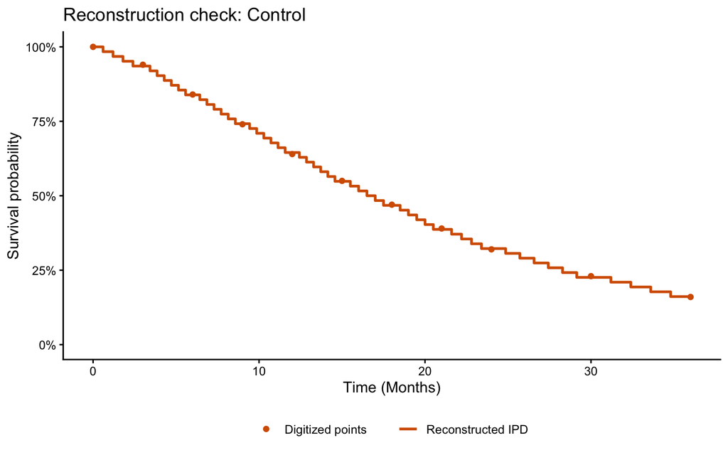

```r
plot_arm_check(arm1_result, arm1_label, arm_colours[1])
```

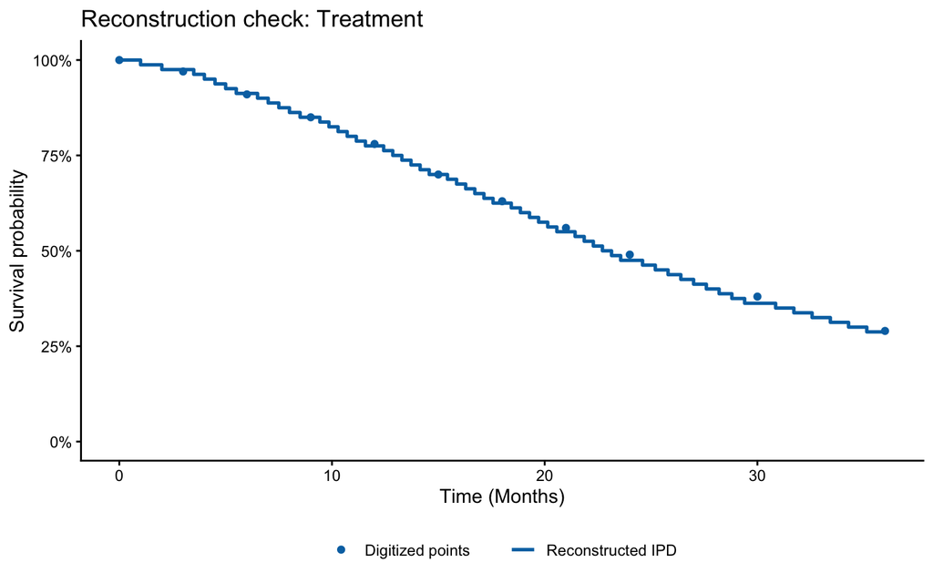

```r
plot_arm_check(arm2_result, arm2_label, arm_colours[2])
```

#### 3.0.6 Compare the two arms

##### 3.0.6.1 Kaplan–Meier, log-rank, and Cox models

The Cox model compares Arm 2 with Arm 1. Because `arm` was explicitly ordered, Arm 1 is the reference group. An HR below 1 indicates a lower instantaneous event hazard in Arm 2 under the proportional hazards interpretation.

```r
survival_object <- survival::Surv(
  time = combined_ipd$time,
  event = combined_ipd$status
)

km_fit <- survival::survfit(
  survival_object ~ arm,
  data = combined_ipd
)

logrank_fit <- survival::survdiff(
  survival_object ~ arm,
  data = combined_ipd
)

logrank_p <- stats::pchisq(
  logrank_fit$chisq,
  df = length(logrank_fit$n) - 1L,
  lower.tail = FALSE
)

cox_fit <- survival::coxph(
  survival_object ~ arm,
  data = combined_ipd
)

cox_result <- broom::tidy(
  cox_fit,
  exponentiate = TRUE,
  conf.int = TRUE
)

hr <- cox_result$estimate[1]
hr_ci_low <- cox_result$conf.low[1]
hr_ci_high <- cox_result$conf.high[1]
hr_p <- cox_result$p.value[1]
```

##### 3.0.6.2 Median OS and event rates

If a curve never reaches 50% survival, its median is not reached and is displayed as `NR`.

```r
format_p <- function(p) {
  ifelse(
    is.na(p),
    "NA",
    ifelse(p < 0.001, "<0.001", sprintf("%.3f", p))
  )
}

median_table <- survminer::surv_median(km_fit) |>
  dplyr::transmute(
    arm = sub("^arm=", "", strata),
    median_os = median
  )

event_table <- combined_ipd |>
  dplyr::group_by(arm) |>
  dplyr::summarise(
    participants = dplyr::n(),
    deaths = sum(status),
    event_rate = 100 * mean(status),
    .groups = "drop"
  ) |>
  dplyr::mutate(arm = as.character(arm))

arm_summary <- event_table |>
  dplyr::left_join(median_table, by = "arm") |>
  dplyr::mutate(
    median_os_display = ifelse(
      is.na(median_os),
      "NR",
      sprintf("%.2f", median_os)
    ),
    event_rate_display = sprintf("%.2f%%", event_rate)
  )

model_summary <- data.frame(
  comparison = paste(arm2_label, "vs", arm1_label),
  hazard_ratio = sprintf("%.2f", hr),
  confidence_interval_95 = sprintf("%.2f to %.2f", hr_ci_low, hr_ci_high),
  cox_p_value = format_p(hr_p),
  logrank_p_value = format_p(logrank_p)
)

arm_summary |>
  dplyr::select(
    arm,
    participants,
    deaths,
    median_os = median_os_display,
    mortality_event_rate = event_rate_display
  )
```

```
# A tibble: 2 x 5
  arm       participants deaths median_os mortality_event_rate
  <chr>            <int>  <int> <chr>     <chr>
1 Control             62     52 16.75     83.87%
2 Treatment           80     57 22.93     71.25%
```

```r
model_summary
```

```
            comparison hazard_ratio confidence_interval_95 cox_p_value
1 Treatment vs Control         0.66           0.45 to 0.96       0.030
  logrank_p_value
1           0.028
```

#### 3.0.7 Final two-arm survival plot

The annotation reports:

- HR for Arm 2 versus Arm 1, with 95% CI;
- Cox and log-rank p-values;
- median OS for each arm; and
- mortality event rate for each arm.

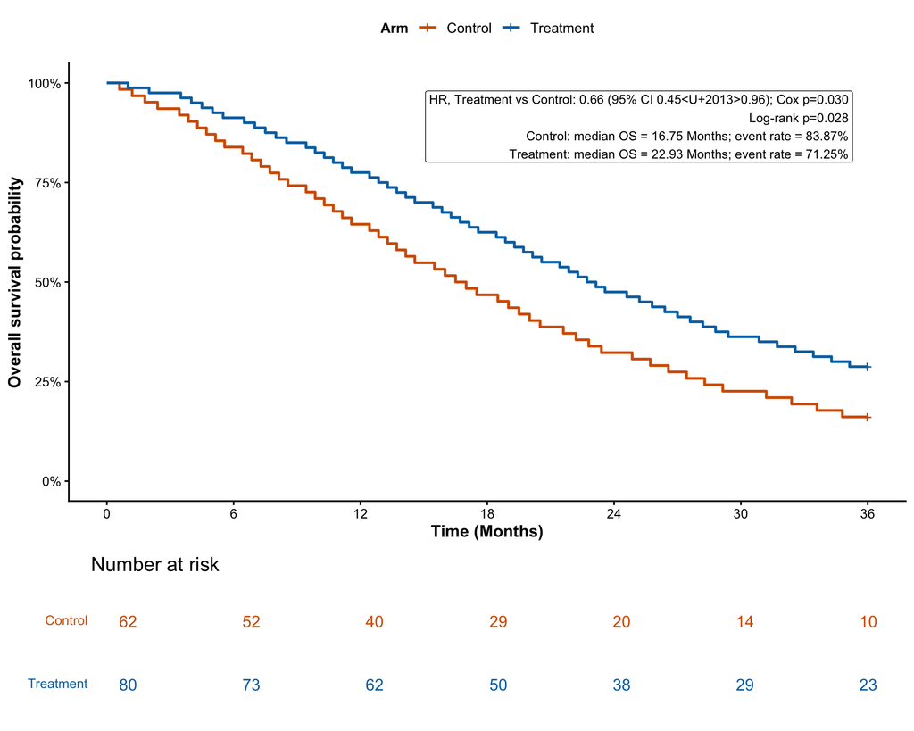

```r
arm_annotation_lines <- paste0(
  arm_summary$arm,
  ": median OS = ",
  arm_summary$median_os_display,
  " ",
  time_unit,
  "; event rate = ",
  arm_summary$event_rate_display
)

annotation_text <- paste(
  sprintf(
    "HR, %s vs %s: %.2f (95%% CI %.2f–%.2f); Cox p%s",
    arm2_label,
    arm1_label,
    hr,
    hr_ci_low,
    hr_ci_high,
    ifelse(hr_p < 0.001, "<0.001", paste0("=", sprintf("%.3f", hr_p)))
  ),
  paste0(
    "Log-rank p",
    ifelse(
      logrank_p < 0.001,
      "<0.001",
      paste0("=", sprintf("%.3f", logrank_p))
    )
  ),
  arm_annotation_lines[1],
  arm_annotation_lines[2],
  sep = "\n"
)

final_km_plot <- survminer::ggsurvplot(
  fit = km_fit,
  data = combined_ipd,
  risk.table = TRUE,
  risk.table.col = "strata",
  risk.table.height = 0.25,
  conf.int = FALSE,
  censor = TRUE,
  palette = arm_colours,
  legend.title = "Arm",
  legend.labs = c(arm1_label, arm2_label),
  xlab = paste0("Time (", time_unit, ")"),
  ylab = "Overall survival probability",
  xlim = c(0, x_axis_max),
  break.time.by = x_axis_break_by,
  surv.scale = "percent",
  ggtheme = ggplot2::theme_classic(base_size = 13),
  tables.theme = survminer::theme_cleantable(base_size = 11)
)

final_km_plot$plot <- final_km_plot$plot +
  ggplot2::annotate(
    "label",
    x = 0.98 * x_axis_max,
    y = 0.98,
    label = annotation_text,
    hjust = 1,
    vjust = 1,
    size = 3.5,
    linewidth = 0.25,
    fill = scales::alpha("white", 0.88)
  ) +
  ggplot2::theme(
    legend.position = "top",
    legend.text = ggplot2::element_text(size = 11),
    legend.title = ggplot2::element_text(size = 11, face = "bold"),
    axis.title = ggplot2::element_text(face = "bold")
  )

print(final_km_plot)
```

##### 3.0.7.1 Sanity checks against the reported results

The first two rows compare each reconstructed median OS with the value reported in the paper. Each passes when the absolute difference is no more than 0.20 months. The HR row passes when $|\ln(\mathrm{HR}_{reported}/\mathrm{HR}_{reconstructed})| \le 0.10$.

```r
scenario1_medians <- stats::setNames(
  arm_summary$median_os,
  arm_summary$arm
)

scenario1_sanity_checks <- run_reconstruction_sanity_checks(
  reconstructed_hr = hr,
  reported_hr = reported_hr_arm2_vs_arm1,
  reconstructed_medians = c(
    scenario1_medians[[arm1_label]],
    scenario1_medians[[arm2_label]]
  ),
  reported_medians = c(
    reported_median_os_arm1,
    reported_median_os_arm2
  ),
  arm_labels = c(arm1_label, arm2_label)
)
```

```
OVERALL RESULT: PASS - all median OS and HR sanity checks passed.
```

```r
display_sanity_check_table(
  scenario1_sanity_checks,
  "Scenario 1 reconstruction sanity checks"
)
```

**Scenario 1 reconstruction sanity checks - Overall result: PASS**

| **Characteristic** | **Median OS: Control**<sup>1</sup> | **Median OS: Treatment**<sup>1</sup> | **HR: Treatment vs Control** |
| --- | --- | --- | --- |
| Reported | 16.75 | 22.93 | 0.66 |
| Reconstructed | 16.75 | 22.93 | 0.66 |
| Absolute difference / log ratio | 0.000 | 0.001 | 0.003 |
| Acceptance limit (<=) | 0.20 | 0.20 | 0.10 |
| Result | PASS | PASS | PASS |

<sup>1</sup> Cross-check and confirm that the original and reconstructed median time to survival have been reported in the same unit of months.

#### 3.0.8 Save the reconstructed data and figure

```r
write.csv(
  combined_ipd,
  "reconstructed_two_arm_ipd.csv",
  row.names = FALSE
)

ggsave(
  filename = "two_arm_kaplan_meier.png",
  plot = final_km_plot$plot,
  width = 10,
  height = 7,
  dpi = 300
)
```

#### 3.0.9 Interpretation template

> In the reconstructed dataset, the hazard of death in **Treatment** relative to **Control** was **0.66** (95% CI **0.45–0.96**; Cox p **0.030**). The log-rank p-value was **0.028**. These estimates are approximate because they were derived from digitized aggregate KM curves under a no-early-censoring assumption.

#### 3.0.10 Suggested reporting language

Always describe these records as **reconstructed** or **pseudo-IPD**. Report the digitization method, available source information, censoring assumptions, curve validation, and any differences between the original published KM curve and the curve reproduced from the reconstructed data.

**Scenario 2 — Numbers-at-risk table available**

Download the complete Scenario 2 R script

**Show the complete Scenario 2 script** — use the copy button in the upper-right corner of the code block**

```r
# Scenario 2: numbers-at-risk table present
# Generated from the Quarto tutorial. Change only values in USER INPUTS.

# ---- packages ----

required_packages <- c(
  "dplyr",
  "purrr",
  "ggplot2",
  "survival",
  "survminer",
  "broom",
  "knitr",
  "gtsummary"
)

packages_to_install <- setdiff(
  required_packages,
  rownames(installed.packages())
)

if (length(packages_to_install) > 0) {
  install.packages(packages_to_install)
}

invisible(
  lapply(required_packages, library, character.only = TRUE)
)

# ---- risk-table-inputs ----

# ====================== USER INPUTS: CHANGE THESE ======================

# STEP 1: Keep TRUE while learning with the dummy data.
# Change this to FALSE when using your own digitized curves and risk tables.
risk_use_demo_data <- TRUE

# STEP 2: Enter Arm 1 information. Arm 1 is the reference group.
risk_arm1_file <- "~/Downloads/arm1_digitized_curve.csv" # CHANGE: Arm 1 CSV
risk_arm1_label <- "Control"                             # CHANGE: paper's arm name

# STEP 3: Copy the risk-table time headings and Arm 1 counts from the paper.
# The first time must be 0, and the first count is the baseline number at risk.
risk_arm1_times <- c(0, 6, 12, 18, 24, 30) # CHANGE: risk-table times
risk_arm1_n <- c(62, 52, 39, 28, 20, 14)   # CHANGE: Arm 1 risk counts

# CHANGE only if the paper reports a total number of events for Arm 1.
# Otherwise leave as NA_integer_.
risk_arm1_total_events <- NA_integer_

# STEP 4: Enter Arm 2 information.
risk_arm2_file <- "~/Downloads/arm2_digitized_curve.csv" # CHANGE: Arm 2 CSV
risk_arm2_label <- "Treatment"                           # CHANGE: paper's arm name

# STEP 5: Copy the risk-table time headings and Arm 2 counts from the paper.
# These vectors must have the same length. Usually both arms share risk times,
# but enter them separately in case the paper reports different intervals.
risk_arm2_times <- c(0, 6, 12, 18, 24, 30) # CHANGE: risk-table times
risk_arm2_n <- c(68, 61, 52, 42, 34, 26)   # CHANGE: Arm 2 risk counts
risk_arm2_total_events <- NA_integer_       # CHANGE only if reported

# STEP 6: Enter the results reported in the paper for the sanity checks.
# The HR must be Arm 2 versus Arm 1. If the paper gives Arm 1 versus Arm 2,
# enter its reciprocal (1 / the reported HR) instead.
risk_reported_hr_arm2_vs_arm1 <- 0.65  # CHANGE: published HR, Arm 2 vs Arm 1
risk_reported_median_os_arm1 <- 18.00  # CHANGE: published Arm 1 median OS, months
risk_reported_median_os_arm2 <- 24.00  # CHANGE: published Arm 2 median OS, months

# STEP 7: Review time and plot settings.
risk_arm1_time_max <- NA_real_ # USUALLY LEAVE UNCHANGED
risk_arm2_time_max <- NA_real_ # USUALLY LEAVE UNCHANGED
time_unit <- "Months"
x_axis_max <- 36                 # CHANGE to the largest time to display
x_axis_break_by <- 6             # CHANGE to the spacing used in the paper (spacing between ticks on the x-axis)
arm_colours <- c("#D55E00", "#0072B2") # OPTIONAL

# ==================== END OF VALUES TO CHANGE =========================

# ---- risk-table-demo-curves ----

risk_demo_control <- data.frame(
  time = c(0, 3, 6, 9, 12, 15, 18, 21, 24, 27, 30, 33, 36),
  survival = c(1.00, 0.94, 0.84, 0.74, 0.64, 0.55, 0.47,
               0.39, 0.32, 0.27, 0.23, 0.19, 0.16)
)

risk_demo_treatment <- data.frame(
  time = c(0, 3, 6, 9, 12, 15, 18, 21, 24, 27, 30, 33, 36),
  survival = c(1.00, 0.97, 0.91, 0.85, 0.78, 0.70, 0.63,
               0.56, 0.49, 0.43, 0.38, 0.33, 0.29)
)

# ---- clean-km-function ----

clamp01 <- function(x) {
  pmin(pmax(x, 0), 1)
}

clean_km <- function(t_raw, S_raw) {
  if (length(t_raw) != length(S_raw)) {
    stop("Time and survival vectors must have the same length.")
  }

  curve <- data.frame(
    time = as.numeric(t_raw),
    survival = as.numeric(S_raw)
  ) |>
    dplyr::filter(!is.na(time), !is.na(survival)) |>
    dplyr::arrange(time) |>
    # At duplicate times, keep the lowest survival value (the full step drop).
    dplyr::group_by(time) |>
    dplyr::summarise(survival = min(survival), .groups = "drop")

  if (nrow(curve) < 2) {
    stop("The digitized curve must contain at least two valid points.")
  }

  if (curve$time[1] < 0) {
    stop("Time values cannot be negative.")
  }

  if (curve$time[1] > 0) {
    curve <- dplyr::bind_rows(
      data.frame(time = 0, survival = 1),
      curve
    )
  } else {
    curve$survival[1] <- 1
  }

  curve$survival <- clamp01(curve$survival)
  curve$survival <- cummin(curve$survival)
  curve
}

# ---- reconstruct-arm-function ----

read_digitized_curve <- function(file) {
  first_attempt <- tryCatch(
    read.csv(file, header = FALSE),
    error = function(e) NULL
  )

  if (!is.null(first_attempt) && ncol(first_attempt) >= 2 &&
      all(!is.na(suppressWarnings(as.numeric(first_attempt[[1]]))))) {
    return(first_attempt[, 1:2])
  }

  second_attempt <- read.csv(file, header = TRUE)
  if (ncol(second_attempt) < 2) {
    stop("The digitized file must contain at least two columns.")
  }
  second_attempt[, 1:2]
}

reconstruct_arm <- function(file = NULL,
                            curve_data = NULL,
                            baseline_N,
                            arm_label,
                            time_max = NA_real_) {
  if (is.null(curve_data)) {
    if (is.null(file) || !file.exists(path.expand(file))) {
      stop("Digitized file not found for arm: ", arm_label)
    }
    raw_curve <- read_digitized_curve(path.expand(file))
  } else {
    raw_curve <- curve_data[, 1:2]
  }

  raw_time <- suppressWarnings(as.numeric(raw_curve[[1]]))
  raw_survival <- suppressWarnings(as.numeric(raw_curve[[2]]))

  if (!is.na(time_max)) {
    raw_time <- raw_time * time_max
  }

  cleaned_curve <- clean_km(raw_time, raw_survival)
  estimated_events <- events_no_censor(
    cleaned_curve$survival,
    baseline_N
  )
  reconstructed_ipd <- build_ipd_uniform(
    cleaned_curve,
    estimated_events,
    baseline_N,
    arm_label
  )

  list(
    curve = cleaned_curve,
    interval_events = estimated_events,
    ipd = reconstructed_ipd
  )
}
```

```r
# ---- arm-diagnostic-function ----

plot_arm_check <- function(result, arm_label, colour) {
  reconstructed_fit <- survival::survfit(
    survival::Surv(time, status) ~ 1,
    data = result$ipd
  )

  reconstructed_curve <- data.frame(
    time = c(0, reconstructed_fit$time),
    survival = c(1, reconstructed_fit$surv),
    source = "Reconstructed IPD"
  )

  ggplot2::ggplot() +
    ggplot2::geom_step(
      data = reconstructed_curve,
      ggplot2::aes(time, survival, colour = source),
      linewidth = 1
    ) +
    ggplot2::geom_point(
      data = result$curve,
      ggplot2::aes(time, survival, shape = "Digitized points"),
      colour = colour,
      size = 2
    ) +
    ggplot2::scale_colour_manual(values = c("Reconstructed IPD" = colour)) +
    ggplot2::scale_shape_manual(values = c("Digitized points" = 16)) +
    ggplot2::scale_y_continuous(
      limits = c(0, 1),
      labels = scales::label_percent(accuracy = 1)
    ) +
    ggplot2::labs(
      title = paste("Reconstruction check:", arm_label),
      x = paste("Time (", time_unit, ")", sep = ""),
      y = "Survival probability",
      colour = NULL,
      shape = NULL
    ) +
    ggplot2::theme_classic(base_size = 12) +
    ggplot2::theme(legend.position = "bottom")
}

# ---- risk-table-reconstruction-function ----

reconstruct_arm_with_risk_table <- function(
    file = NULL,
    curve_data = NULL,
    risk_times,
    numbers_at_risk,
    arm_label,
    total_events = NA_integer_,
    time_max = NA_real_,
    max_iterations = 1000L) {

  if (is.null(curve_data)) {
    if (is.null(file) || !file.exists(path.expand(file))) {
      stop("Digitized file not found for arm: ", arm_label)
    }
    raw_curve <- read_digitized_curve(path.expand(file))
  } else {
    raw_curve <- curve_data[, 1:2]
  }

  raw_time <- suppressWarnings(as.numeric(raw_curve[[1]]))
  raw_survival <- suppressWarnings(as.numeric(raw_curve[[2]]))
  if (!is.na(time_max)) raw_time <- raw_time * time_max

  curve <- clean_km(raw_time, raw_survival)
  tS <- curve$time
  S <- curve$survival

  risk_times <- as.numeric(risk_times)
  numbers_at_risk <- as.integer(numbers_at_risk)

  if (length(risk_times) != length(numbers_at_risk)) {
    stop("risk_times and numbers_at_risk must have equal lengths.")
  }
  if (length(risk_times) < 2L) {
    stop("At least two reported risk times are required for this workflow.")
  }
  if (risk_times[1] != 0 || any(diff(risk_times) <= 0)) {
    stop("Risk times must begin at 0 and be strictly increasing.")
  }
  if (any(numbers_at_risk < 0) || any(diff(numbers_at_risk) > 0)) {
    stop("Numbers at risk must be nonnegative and non-increasing.")
  }
  if (max(risk_times) >= max(tS)) {
    stop("The last risk-table time must be earlier than the last digitized time.")
  }

  lower <- vapply(
    risk_times,
    function(x) min(which(tS >= x)),
    integer(1)
  )
  upper <- vapply(
    c(risk_times[-1], Inf),
    function(x) max(which(tS < x)),
    integer(1)
  )

  n_intervals <- length(numbers_at_risk)
  n_t <- upper[n_intervals]
  baseline_n <- numbers_at_risk[1]
  effective_risk <- numbers_at_risk

  n_hat <- rep(baseline_n + 1L, n_t + 1L)
  censored <- integer(n_t)
  events <- integer(n_t)
  km_hat <- rep(1, n_t)
  last_event_index <- rep(1L, n_intervals)
  number_censored <- integer(n_intervals)

  allocate_censoring <- function(start_index, end_time_index, n_censor) {
    allocation <- integer(n_t)
    if (n_censor <= 0L || end_time_index <= start_index) return(allocation)

    censor_times <- tS[start_index] +
      seq_len(n_censor) *
      (tS[end_time_index] - tS[start_index]) / (n_censor + 1L)

    allocation[start_index:(end_time_index - 1L)] <- hist(
      censor_times,
      breaks = tS[start_index:end_time_index],
      plot = FALSE,
      include.lowest = TRUE
    )$counts
    allocation
  }

  run_interval <- function(start_index, end_index, risk_at_start,
                           previous_event_index, censor_allocation,
                           n_hat_in, events_in, km_hat_in) {
    n_local <- n_hat_in
    d_local <- events_in
    km_local <- km_hat_in
    n_local[start_index] <- risk_at_start
    last <- previous_event_index

    for (k in start_index:end_index) {
      if (start_index == 1L && k == 1L) {
        d_local[k] <- 0L
        km_local[k] <- 1
      } else if (n_local[k] <= 0 || km_local[last] <= 0) {
        d_local[k] <- 0L
        km_local[k] <- km_local[last]
      } else {
        proposed <- round(n_local[k] * (1 - S[k] / km_local[last]))
        d_local[k] <- max(0L, min(as.integer(proposed), n_local[k]))
        km_local[k] <- km_local[last] * (1 - d_local[k] / n_local[k])
      }

      n_local[k + 1L] <- n_local[k] - d_local[k] - censor_allocation[k]
      if (n_local[k + 1L] < 0L) {
        censor_allocation[k] <- max(0L, n_local[k] - d_local[k])
        n_local[k + 1L] <- 0L
      }
      if (d_local[k] > 0L) last <- k
    }

    list(
      n_hat = n_local,
      events = d_local,
      km_hat = km_local,
      censoring = censor_allocation,
      last = last
    )
  }

  # Reconcile all intervals that end at another published risk count.
  for (i in seq_len(n_intervals - 1L)) {
    start_index <- lower[i]
    end_index <- upper[i]
    next_start <- lower[i + 1L]

    initial_censor <- round(
      effective_risk[i] * S[next_start] / S[start_index] -
        effective_risk[i + 1L]
    )
    number_censored[i] <- max(0L, as.integer(initial_censor))

    converged <- FALSE
    for (iteration in seq_len(max_iterations)) {
      interval_censoring <- allocate_censoring(
        start_index,
        next_start,
        number_censored[i]
      )
      censored[start_index:end_index] <-
        interval_censoring[start_index:end_index]

      result <- run_interval(
        start_index,
        end_index,
        effective_risk[i],
        last_event_index[i],
        censored,
        n_hat,
        events,
        km_hat
      )

      n_hat <- result$n_hat
      events <- result$events
      km_hat <- result$km_hat
      censored <- result$censoring
```

```r
      difference <- n_hat[next_start] - effective_risk[i + 1L]
      if (difference == 0L) {
        converged <- TRUE
        break
      }

      revised_censor <- number_censored[i] + difference
      if (revised_censor < 0L && number_censored[i] == 0L) break
      number_censored[i] <- max(0L, revised_censor)
    }

    if (!converged && n_hat[next_start] < effective_risk[i + 1L]) {
      warning(
        "Published risk count was not attainable in interval ", i,
        "; using the largest internally consistent count."
      )
      effective_risk[i + 1L] <- n_hat[next_start]
    }
    last_event_index[i + 1L] <- result$last
  }

  # Estimate censoring after the final reported risk time.
  previous_span <- tS[upper[n_intervals - 1L]] - tS[lower[1L]]
  final_span <- tS[upper[n_intervals]] - tS[lower[n_intervals]]
  initial_final_censor <- if (previous_span > 0) {
    round(sum(number_censored[seq_len(n_intervals - 1L)]) *
            final_span / previous_span)
  } else {
    0L
  }
  initial_final_censor <- min(
    max(0L, as.integer(initial_final_censor)),
    effective_risk[n_intervals]
  )

  base_n_hat <- n_hat
  base_events <- events
  base_km_hat <- km_hat
  base_censored <- censored

  evaluate_final_interval <- function(final_censor_count) {
    final_allocation <- allocate_censoring(
      lower[n_intervals],
      upper[n_intervals],
      final_censor_count
    )
    censor_candidate <- base_censored
    censor_candidate[lower[n_intervals]:upper[n_intervals]] <-
      final_allocation[lower[n_intervals]:upper[n_intervals]]

    run_interval(
      lower[n_intervals],
      upper[n_intervals],
      effective_risk[n_intervals],
      last_event_index[n_intervals],
      censor_candidate,
      base_n_hat,
      base_events,
      base_km_hat
    )
  }

  if (is.na(total_events)) {
    final_result <- evaluate_final_interval(initial_final_censor)
    number_censored[n_intervals] <- initial_final_censor
  } else {
    candidates <- 0:effective_risk[n_intervals]
    candidate_results <- lapply(candidates, evaluate_final_interval)
    candidate_event_totals <- vapply(
      candidate_results,
      function(x) sum(x$events),
      integer(1)
    )
    best <- which.min(abs(candidate_event_totals - total_events))
    final_result <- candidate_results[[best]]
    number_censored[n_intervals] <- candidates[best]
    if (candidate_event_totals[best] != total_events) {
      warning("The reported total event count could only be approximated.")
    }
  }

  n_hat <- final_result$n_hat
  events <- final_result$events
  km_hat <- final_result$km_hat
  censored <- final_result$censoring

  event_times <- rep(tS[seq_len(n_t)], events[seq_len(n_t)])
  censor_times <- unlist(
    lapply(seq_len(n_t - 1L), function(j) {
      rep((tS[j] + tS[j + 1L]) / 2, censored[j])
    }),
    use.names = FALSE
  )

  assigned <- length(event_times) + length(censor_times)
  if (assigned > baseline_n) {
    stop("Events plus censoring exceed the baseline sample size.")
  }

  remaining <- baseline_n - assigned
  ipd <- data.frame(
    time = c(event_times, censor_times, rep(tS[n_t], remaining)),
    status = c(
      rep(1L, length(event_times)),
      rep(0L, length(censor_times) + remaining)
    ),
    arm = arm_label
  )

  reconstructed_fit <- survival::survfit(
    survival::Surv(time, status) ~ 1,
    data = ipd
  )
  reconstructed_risk <- summary(
    reconstructed_fit,
    times = risk_times,
    extend = TRUE
  )$n.risk

  list(
    curve = curve,
    ipd = ipd,
    events_by_point = events[seq_len(n_t)],
    censored_by_point = censored[seq_len(n_t)],
    estimated_risk = data.frame(
      time = risk_times,
      published = numbers_at_risk,
      used_by_algorithm = effective_risk,
      reconstructed = reconstructed_risk
    )
  )
}

# ---- run-risk-table-reconstruction ----

risk_arm1_result <- reconstruct_arm_with_risk_table(
  file = if (!risk_use_demo_data) risk_arm1_file else NULL,
  curve_data = if (risk_use_demo_data) risk_demo_control else NULL,
  risk_times = risk_arm1_times,
  numbers_at_risk = risk_arm1_n,
  arm_label = risk_arm1_label,
  total_events = risk_arm1_total_events,
  time_max = risk_arm1_time_max
)

risk_arm2_result <- reconstruct_arm_with_risk_table(
  file = if (!risk_use_demo_data) risk_arm2_file else NULL,
  curve_data = if (risk_use_demo_data) risk_demo_treatment else NULL,
  risk_times = risk_arm2_times,
  numbers_at_risk = risk_arm2_n,
  arm_label = risk_arm2_label,
  total_events = risk_arm2_total_events,
  time_max = risk_arm2_time_max
)

combined_ipd_with_risk <- dplyr::bind_rows(
  risk_arm1_result$ipd,
  risk_arm2_result$ipd
) |>
  dplyr::mutate(
    status = as.integer(status),
    arm = factor(arm, levels = c(risk_arm1_label, risk_arm2_label))
  )

stopifnot(
  nrow(risk_arm1_result$ipd) == risk_arm1_n[1],
  nrow(risk_arm2_result$ipd) == risk_arm2_n[1],
  all(combined_ipd_with_risk$status %in% c(0L, 1L)),
  !anyNA(combined_ipd_with_risk)
)

head(combined_ipd_with_risk)

# ---- risk-count-validation ----

dplyr::bind_rows(
  dplyr::mutate(risk_arm1_result$estimated_risk, arm = risk_arm1_label),
  dplyr::mutate(risk_arm2_result$estimated_risk, arm = risk_arm2_label)
) |>
  dplyr::select(arm, time, published, used_by_algorithm, reconstructed)

# ---- risk-arm-checks ----

plot_arm_check(risk_arm1_result, risk_arm1_label, arm_colours[1])
plot_arm_check(risk_arm2_result, risk_arm2_label, arm_colours[2])

# ---- risk-table-analysis ----

risk_km_fit <- survival::survfit(
  survival::Surv(time, status) ~ arm,
  data = combined_ipd_with_risk
)

risk_logrank <- survival::survdiff(
  survival::Surv(time, status) ~ arm,
  data = combined_ipd_with_risk
)
risk_logrank_p <- stats::pchisq(
  risk_logrank$chisq,
  df = length(risk_logrank$n) - 1L,
  lower.tail = FALSE
)

risk_cox <- survival::coxph(
  survival::Surv(time, status) ~ arm,
  data = combined_ipd_with_risk
)
risk_cox_result <- broom::tidy(
  risk_cox,
  exponentiate = TRUE,
  conf.int = TRUE
)

risk_hr <- risk_cox_result$estimate[1]
risk_hr_low <- risk_cox_result$conf.low[1]
risk_hr_high <- risk_cox_result$conf.high[1]
risk_hr_p <- risk_cox_result$p.value[1]
```

```r
risk_medians <- survminer::surv_median(risk_km_fit) |>
  dplyr::transmute(
    arm = sub("^arm=", "", strata),
    median_os = median
  )

risk_arm_summary <- combined_ipd_with_risk |>
  dplyr::group_by(arm) |>
  dplyr::summarise(
    participants = dplyr::n(),
    deaths = sum(status),
    event_rate = 100 * mean(status),
    .groups = "drop"
  ) |>
  dplyr::mutate(arm = as.character(arm)) |>
  dplyr::left_join(risk_medians, by = "arm") |>
  dplyr::mutate(
    median_display = ifelse(
      is.na(median_os), "NR", sprintf("%.2f", median_os)
    ),
    event_rate_display = sprintf("%.2f%%", event_rate)
  )

risk_arm_summary |>
  dplyr::select(
    arm,
    participants,
    deaths,
    median_os = median_display,
    mortality_event_rate = event_rate_display
  )

# ---- risk-table-final-plot ----

risk_annotation <- paste(
  sprintf(
    "HR, %s vs %s: %.2f (95%% CI %.2f–%.2f); Cox p%s",
    risk_arm2_label,
    risk_arm1_label,
    risk_hr,
    risk_hr_low,
    risk_hr_high,
    ifelse(
      risk_hr_p < 0.001,
      "<0.001",
      paste0("=", sprintf("%.3f", risk_hr_p))
    )
  ),
  paste0(
    "Log-rank p",
    ifelse(
      risk_logrank_p < 0.001,
      "<0.001",
      paste0("=", sprintf("%.3f", risk_logrank_p))
    )
  ),
  paste0(
    risk_arm_summary$arm,
    ": median OS = ", risk_arm_summary$median_display, " ", time_unit,
    "; event rate = ", risk_arm_summary$event_rate_display,
    collapse = "\n"
  ),
  sep = "\n"
)

risk_final_plot <- survminer::ggsurvplot(
  risk_km_fit,
  data = combined_ipd_with_risk,
  risk.table = TRUE,
  risk.table.col = "strata",
  risk.table.height = 0.20,
  cumcensor = TRUE,
  cumcensor.col = "strata",
  cumcensor.height = 0.18,
  cumcensor.title = "Cumulative number censored",
  conf.int = FALSE,
  palette = arm_colours,
  legend.title = "Arm",
  legend.labs = c(risk_arm1_label, risk_arm2_label),
  xlab = paste0("Time (", time_unit, ")"),
  ylab = "Overall survival probability",
  xlim = c(0, x_axis_max),
  break.time.by = x_axis_break_by,
  surv.scale = "percent",
  ggtheme = ggplot2::theme_classic(base_size = 13),
  tables.theme = survminer::theme_cleantable(base_size = 11)
)

risk_final_plot$plot <- risk_final_plot$plot +
  ggplot2::annotate(
    "label",
    x = 0.98 * x_axis_max,
    y = 0.98,
    label = risk_annotation,
    hjust = 1,
    vjust = 1,
    size = 3.5,
    linewidth = 0.25,
    fill = scales::alpha("white", 0.88)
  ) +
  ggplot2::theme(
    legend.position = "top",
    axis.title = ggplot2::element_text(face = "bold")
  )

print(risk_final_plot)

# ---- sanity-check-function ----

run_reconstruction_sanity_checks <- function(
    reconstructed_hr,
    reported_hr,
    reconstructed_medians,
    reported_medians,
    arm_labels,
    median_tolerance_months = 0.20,
    log_hr_tolerance = 0.10) {

  if (length(reconstructed_hr) != 1L || !is.finite(reconstructed_hr) ||
      reconstructed_hr <= 0 || length(reported_hr) != 1L ||
      !is.finite(reported_hr) || reported_hr <= 0) {
    stop("Reported and reconstructed HRs must each be one positive number.")
  }

  if (length(reconstructed_medians) != 2L ||
      length(reported_medians) != 2L || length(arm_labels) != 2L) {
    stop("Supply exactly two reconstructed medians, reported medians, and arm labels.")
  }

  median_difference <- abs(reconstructed_medians - reported_medians)
  median_pass <- is.finite(median_difference) &
    median_difference <= median_tolerance_months + sqrt(.Machine$double.eps)

  log_hr_difference <- abs(log(reported_hr / reconstructed_hr))
  hr_pass <- is.finite(log_hr_difference) &&
    log_hr_difference <= log_hr_tolerance + sqrt(.Machine$double.eps)

  results <- data.frame(
    check = c(
      paste0("Median OS: ", arm_labels[1]),
      paste0("Median OS: ", arm_labels[2]),
      paste0("HR: ", arm_labels[2], " vs ", arm_labels[1])
    ),
    reported = sprintf("%.2f", c(reported_medians, reported_hr)),
    reconstructed = sprintf("%.2f", c(reconstructed_medians, reconstructed_hr)),
    comparison = c(
      sprintf("absolute difference = %.2f months", median_difference),
      sprintf("absolute log ratio = %.3f", log_hr_difference)
    ),
    acceptance_rule = c(
      rep(sprintf("difference <= %.2f months", median_tolerance_months), 2L),
      sprintf("absolute log ratio <= %.2f", log_hr_tolerance)
    ),
    result = ifelse(c(median_pass, hr_pass), "PASS", "FAIL"),
    check.names = FALSE
  )

  display_data <- data.frame(
    check = results$check,
    reported = c(reported_medians, reported_hr),
    reconstructed = c(reconstructed_medians, reconstructed_hr),
    diagnostic = c(median_difference, log_hr_difference),
    acceptance_limit = c(
      median_tolerance_months,
      median_tolerance_months,
      log_hr_tolerance
    ),
    passed = as.integer(c(median_pass, hr_pass)),
    check.names = FALSE
  )

  failed_checks <- results$check[results$result == "FAIL"]
  if (length(failed_checks) == 0L) {
    cat("\nOVERALL RESULT: PASS - all median OS and HR sanity checks passed.\n")
  } else {
    cat("\nOVERALL RESULT: FAIL - the following check(s) did not pass:\n")
    cat(paste0("- ", failed_checks, collapse = "\n"), "\n")
  }

  invisible(
    list(
      results = results,
      display_data = display_data,
      all_pass = length(failed_checks) == 0L
    )
  )
}

display_sanity_check_table <- function(checks, table_title) {
  overall_result <- ifelse(checks$all_pass, "PASS", "FAIL")
  full_title <- paste0(table_title, " - Overall result: ", overall_result)

  table_data <- checks$display_data |>
    dplyr::mutate(
      check = factor(check, levels = check)
    )

  formatted_table <- table_data |>
    gtsummary::tbl_summary(
      by = check,
      include = -check,
      type = dplyr::everything() ~ "continuous",
      statistic = dplyr::everything() ~ "{mean}",
      digits = list(
        reported ~ 2,
        reconstructed ~ 2,
        diagnostic ~ 3,
        acceptance_limit ~ 2,
        passed ~ 0
      ),
      label = list(
        reported ~ "Reported",
        reconstructed ~ "Reconstructed",
        diagnostic ~ "Absolute difference / log ratio",
        acceptance_limit ~ "Acceptance limit (<=)",
        passed ~ "Result"
      ),
      missing = "no"
    ) |>
    gtsummary::modify_header(
      gtsummary::all_stat_cols() ~ "**{level}**"
    ) |>
    gtsummary::modify_footnote_header(
      footnote = NA_character_,
      columns = gtsummary::all_stat_cols()
    ) |>
    gtsummary::modify_footnote_header(
      footnote = paste0(
        "Cross-check and confirm that the original and reconstructed median ",
        "time to survival have been reported in the same unit of months."
      ),
      columns = c(stat_1, stat_2),
      replace = TRUE
    ) |>
    gtsummary::modify_table_body(
      ~ .x |>
        dplyr::mutate(
          dplyr::across(
            dplyr::starts_with("stat_"),
            ~ ifelse(
              variable == "passed",
              ifelse(.x == "1", "PASS", "FAIL"),
              .x
            )
          )
        )
    ) |>
    gtsummary::bold_labels() |>
    gtsummary::modify_caption(paste0("**", full_title, "**"))
```

```r
  # Quarto renders the gtsummary object as a publication-ready table.
  if (knitr::is_html_output()) {
    return(formatted_table)
  }

  # Printing a gtsummary table interactively opens its HTML output in the
  # RStudio Viewer without calling the native spreadsheet Data Viewer.
  if (interactive()) {
    tryCatch(
      print(formatted_table),
      error = function(error_condition) {
        message("The HTML Viewer could not be opened; using the console table.")
      }
    )
  }

  # Always retain a console fallback and keep the underlying data accessible.
  print(checks$results, row.names = FALSE)
  invisible(checks$results)
}

# ---- scenario-2-sanity-check ----

scenario2_medians <- stats::setNames(
  risk_arm_summary$median_os,
  risk_arm_summary$arm
)

scenario2_sanity_checks <- run_reconstruction_sanity_checks(
  reconstructed_hr = risk_hr,
  reported_hr = risk_reported_hr_arm2_vs_arm1,
  reconstructed_medians = c(
    scenario2_medians[[risk_arm1_label]],
    scenario2_medians[[risk_arm2_label]]
  ),
  reported_medians = c(
    risk_reported_median_os_arm1,
    risk_reported_median_os_arm2
  ),
  arm_labels = c(risk_arm1_label, risk_arm2_label)
)

display_sanity_check_table(
  scenario2_sanity_checks,
  "Scenario 2 reconstruction sanity checks"
)
```

When a publication reports numbers at risk beneath the KM plot, use those counts to estimate censoring within each reported interval. This is the Guyot-style reconstruction and generally contains more information than the baseline-only workflow.

#### 3.0.11 User inputs for two arms

Enter one digitized curve and one risk table for each arm. The risk times and numbers at risk must have equal lengths, begin at time 0, and follow the time scale used in the digitized files.

**ImportantBefore running Scenario 2 with your own data**

Change **only** the clearly marked values in the `USER INPUTS` block below:

1. Change `risk_use_demo_data` from `TRUE` to `FALSE`.
2. Change both CSV file paths and arm labels.
3. Transcribe the risk-table time headings into each `_times` vector.
4. Transcribe the numbers printed under each arm into the matching `_n` vector.
5. Confirm that every `_times` vector and its `_n` vector contain the same number of entries. The first risk count is the baseline number at risk at time 0.
6. Enter the published HR for Arm 2 versus Arm 1 and the published median OS for each arm.

Example: if the paper reports risk-table times 0, 6, 12, and 18 months and counts 80, 62, 41, and 20, enter `times <- c(0, 6, 12, 18)` and `n <- c(80, 62, 41, 20)`.

```r
# ====================== USER INPUTS: CHANGE THESE ======================

# STEP 1: Keep TRUE while learning with the dummy data.
# Change this to FALSE when using your own digitized curves and risk tables.
risk_use_demo_data <- TRUE

# STEP 2: Enter Arm 1 information. Arm 1 is the reference group.
risk_arm1_file <- "~/Downloads/arm1_digitized_curve.csv" # CHANGE: Arm 1 CSV
risk_arm1_label <- "Control"                             # CHANGE: paper's arm name

# STEP 3: Copy the risk-table time headings and Arm 1 counts from the paper.
# The first time must be 0, and the first count is the baseline number at risk.
risk_arm1_times <- c(0, 6, 12, 18, 24, 30) # CHANGE: risk-table times
risk_arm1_n <- c(62, 52, 39, 28, 20, 14)   # CHANGE: Arm 1 risk counts

# CHANGE only if the paper reports a total number of events for Arm 1.
# Otherwise leave as NA_integer_.
risk_arm1_total_events <- NA_integer_

# STEP 4: Enter Arm 2 information.
risk_arm2_file <- "~/Downloads/arm2_digitized_curve.csv" # CHANGE: Arm 2 CSV
risk_arm2_label <- "Treatment"                           # CHANGE: paper's arm name

# STEP 5: Copy the risk-table time headings and Arm 2 counts from the paper.
# These vectors must have the same length. Usually both arms share risk times,
# but enter them separately in case the paper reports different intervals.
risk_arm2_times <- c(0, 6, 12, 18, 24, 30) # CHANGE: risk-table times
risk_arm2_n <- c(68, 61, 52, 42, 34, 26)   # CHANGE: Arm 2 risk counts
risk_arm2_total_events <- NA_integer_       # CHANGE only if reported

# STEP 6: Enter the results reported in the paper for the sanity checks.
# The HR must be Arm 2 versus Arm 1. If the paper gives Arm 1 versus Arm 2,
# enter its reciprocal (1 / the reported HR) instead.
risk_reported_hr_arm2_vs_arm1 <- 0.65  # CHANGE: published HR, Arm 2 vs Arm 1
risk_reported_median_os_arm1 <- 18.00  # CHANGE: published Arm 1 median OS, months
risk_reported_median_os_arm2 <- 24.00  # CHANGE: published Arm 2 median OS, months

# STEP 7: Review time and plot settings.
risk_arm1_time_max <- NA_real_ # USUALLY LEAVE UNCHANGED
risk_arm2_time_max <- NA_real_ # USUALLY LEAVE UNCHANGED
time_unit <- "Months"
x_axis_max <- 36                 # CHANGE to the largest time to display
x_axis_break_by <- 6             # CHANGE to the spacing used in the paper (spacing between ticks on the x-axis)
arm_colours <- c("#D55E00", "#0072B2") # OPTIONAL

# ==================== END OF VALUES TO CHANGE =========================
```

**Tip**

If a total event count is reported for an arm, replace `NA_integer_` with that count. The function searches possible censor counts in the final interval and uses the value that most closely reproduces the reported event total.

#### 3.0.12 Dummy digitized curves

```r
risk_demo_control <- data.frame(
  time = c(0, 3, 6, 9, 12, 15, 18, 21, 24, 27, 30, 33, 36),
  survival = c(1.00, 0.94, 0.84, 0.74, 0.64, 0.55, 0.47,
               0.39, 0.32, 0.27, 0.23, 0.19, 0.16)
)

risk_demo_treatment <- data.frame(
  time = c(0, 3, 6, 9, 12, 15, 18, 21, 24, 27, 30, 33, 36),
  survival = c(1.00, 0.97, 0.91, 0.85, 0.78, 0.70, 0.63,
               0.56, 0.49, 0.43, 0.38, 0.33, 0.29)
)
```

#### 3.0.13 Guyot-style reconstruction function

The function below follows the supplied algorithm while adding validation, iteration limits, and protection against negative risk sets. It performs five operations:

1. maps each reported risk time to the digitized coordinates;
2. estimates censoring in each risk-table interval;
3. iteratively reconciles the estimated risk set with the published risk count;
4. estimates event counts that reproduce the digitized KM probabilities; and
5. expands event and censor counts into reconstructed patient records.

```r
reconstruct_arm_with_risk_table <- function(
    file = NULL,
    curve_data = NULL,
    risk_times,
    numbers_at_risk,
    arm_label,
    total_events = NA_integer_,
    time_max = NA_real_,
    max_iterations = 1000L) {

  if (is.null(curve_data)) {
    if (is.null(file) || !file.exists(path.expand(file))) {
      stop("Digitized file not found for arm: ", arm_label)
    }
    raw_curve <- read_digitized_curve(path.expand(file))
  } else {
    raw_curve <- curve_data[, 1:2]
  }

  raw_time <- suppressWarnings(as.numeric(raw_curve[[1]]))
  raw_survival <- suppressWarnings(as.numeric(raw_curve[[2]]))
  if (!is.na(time_max)) raw_time <- raw_time * time_max

  curve <- clean_km(raw_time, raw_survival)
  tS <- curve$time
  S <- curve$survival

  risk_times <- as.numeric(risk_times)
  numbers_at_risk <- as.integer(numbers_at_risk)

  if (length(risk_times) != length(numbers_at_risk)) {
    stop("risk_times and numbers_at_risk must have equal lengths.")
  }
  if (length(risk_times) < 2L) {
    stop("At least two reported risk times are required for this workflow.")
  }
  if (risk_times[1] != 0 || any(diff(risk_times) <= 0)) {
    stop("Risk times must begin at 0 and be strictly increasing.")
  }
  if (any(numbers_at_risk < 0) || any(diff(numbers_at_risk) > 0)) {
    stop("Numbers at risk must be nonnegative and non-increasing.")
  }
  if (max(risk_times) >= max(tS)) {
    stop("The last risk-table time must be earlier than the last digitized time.")
  }

  lower <- vapply(
    risk_times,
    function(x) min(which(tS >= x)),
    integer(1)
  )
  upper <- vapply(
    c(risk_times[-1], Inf),
    function(x) max(which(tS < x)),
    integer(1)
  )

  n_intervals <- length(numbers_at_risk)
  n_t <- upper[n_intervals]
  baseline_n <- numbers_at_risk[1]
  effective_risk <- numbers_at_risk

  n_hat <- rep(baseline_n + 1L, n_t + 1L)
  censored <- integer(n_t)
  events <- integer(n_t)
  km_hat <- rep(1, n_t)
  last_event_index <- rep(1L, n_intervals)
  number_censored <- integer(n_intervals)

  allocate_censoring <- function(start_index, end_time_index, n_censor) {
    allocation <- integer(n_t)
    if (n_censor <= 0L || end_time_index <= start_index) return(allocation)

    censor_times <- tS[start_index] +
      seq_len(n_censor) *
      (tS[end_time_index] - tS[start_index]) / (n_censor + 1L)

    allocation[start_index:(end_time_index - 1L)] <- hist(
      censor_times,
      breaks = tS[start_index:end_time_index],
      plot = FALSE,
      include.lowest = TRUE
    )$counts
    allocation
  }

  run_interval <- function(start_index, end_index, risk_at_start,
                           previous_event_index, censor_allocation,
                           n_hat_in, events_in, km_hat_in) {
    n_local <- n_hat_in
    d_local <- events_in
    km_local <- km_hat_in
    n_local[start_index] <- risk_at_start
    last <- previous_event_index

    for (k in start_index:end_index) {
      if (start_index == 1L && k == 1L) {
        d_local[k] <- 0L
        km_local[k] <- 1
      } else if (n_local[k] <= 0 || km_local[last] <= 0) {
        d_local[k] <- 0L
        km_local[k] <- km_local[last]
      } else {
        proposed <- round(n_local[k] * (1 - S[k] / km_local[last]))
        d_local[k] <- max(0L, min(as.integer(proposed), n_local[k]))
        km_local[k] <- km_local[last] * (1 - d_local[k] / n_local[k])
      }

      n_local[k + 1L] <- n_local[k] - d_local[k] - censor_allocation[k]
      if (n_local[k + 1L] < 0L) {
        censor_allocation[k] <- max(0L, n_local[k] - d_local[k])
        n_local[k + 1L] <- 0L
      }
      if (d_local[k] > 0L) last <- k
    }

    list(
      n_hat = n_local,
      events = d_local,
      km_hat = km_local,
      censoring = censor_allocation,
      last = last
    )
  }

  # Reconcile all intervals that end at another published risk count.
  for (i in seq_len(n_intervals - 1L)) {
    start_index <- lower[i]
    end_index <- upper[i]
    next_start <- lower[i + 1L]

    initial_censor <- round(
      effective_risk[i] * S[next_start] / S[start_index] -
        effective_risk[i + 1L]
    )
    number_censored[i] <- max(0L, as.integer(initial_censor))

    converged <- FALSE
    for (iteration in seq_len(max_iterations)) {
      interval_censoring <- allocate_censoring(
        start_index,
        next_start,
        number_censored[i]
      )
      censored[start_index:end_index] <-
        interval_censoring[start_index:end_index]

      result <- run_interval(
        start_index,
        end_index,
        effective_risk[i],
        last_event_index[i],
        censored,
        n_hat,
        events,
        km_hat
      )

      n_hat <- result$n_hat
      events <- result$events
      km_hat <- result$km_hat
      censored <- result$censoring

      difference <- n_hat[next_start] - effective_risk[i + 1L]
      if (difference == 0L) {
        converged <- TRUE
        break
      }

      revised_censor <- number_censored[i] + difference
      if (revised_censor < 0L && number_censored[i] == 0L) break
      number_censored[i] <- max(0L, revised_censor)
    }

    if (!converged && n_hat[next_start] < effective_risk[i + 1L]) {
      warning(
        "Published risk count was not attainable in interval ", i,
        "; using the largest internally consistent count."
      )
      effective_risk[i + 1L] <- n_hat[next_start]
    }
    last_event_index[i + 1L] <- result$last
  }

  # Estimate censoring after the final reported risk time.
  previous_span <- tS[upper[n_intervals - 1L]] - tS[lower[1L]]
  final_span <- tS[upper[n_intervals]] - tS[lower[n_intervals]]
  initial_final_censor <- if (previous_span > 0) {
    round(sum(number_censored[seq_len(n_intervals - 1L)]) *
            final_span / previous_span)
  } else {
    0L
  }
  initial_final_censor <- min(
    max(0L, as.integer(initial_final_censor)),
    effective_risk[n_intervals]
  )

  base_n_hat <- n_hat
  base_events <- events
  base_km_hat <- km_hat
  base_censored <- censored

  evaluate_final_interval <- function(final_censor_count) {
    final_allocation <- allocate_censoring(
      lower[n_intervals],
      upper[n_intervals],
      final_censor_count
    )
    censor_candidate <- base_censored
    censor_candidate[lower[n_intervals]:upper[n_intervals]] <-
      final_allocation[lower[n_intervals]:upper[n_intervals]]

    run_interval(
      lower[n_intervals],
      upper[n_intervals],
      effective_risk[n_intervals],
      last_event_index[n_intervals],
      censor_candidate,
      base_n_hat,
      base_events,
      base_km_hat
    )
  }

  if (is.na(total_events)) {
    final_result <- evaluate_final_interval(initial_final_censor)
    number_censored[n_intervals] <- initial_final_censor
  } else {
    candidates <- 0:effective_risk[n_intervals]
    candidate_results <- lapply(candidates, evaluate_final_interval)
    candidate_event_totals <- vapply(
      candidate_results,
      function(x) sum(x$events),
      integer(1)
    )
    best <- which.min(abs(candidate_event_totals - total_events))
    final_result <- candidate_results[[best]]
    number_censored[n_intervals] <- candidates[best]
    if (candidate_event_totals[best] != total_events) {
      warning("The reported total event count could only be approximated.")
    }
  }

  n_hat <- final_result$n_hat
  events <- final_result$events
  km_hat <- final_result$km_hat
  censored <- final_result$censoring

  event_times <- rep(tS[seq_len(n_t)], events[seq_len(n_t)])
  censor_times <- unlist(
    lapply(seq_len(n_t - 1L), function(j) {
      rep((tS[j] + tS[j + 1L]) / 2, censored[j])
    }),
    use.names = FALSE
  )

  assigned <- length(event_times) + length(censor_times)
  if (assigned > baseline_n) {
    stop("Events plus censoring exceed the baseline sample size.")
  }

  remaining <- baseline_n - assigned
  ipd <- data.frame(
    time = c(event_times, censor_times, rep(tS[n_t], remaining)),
    status = c(
      rep(1L, length(event_times)),
      rep(0L, length(censor_times) + remaining)
    ),
    arm = arm_label
  )

  reconstructed_fit <- survival::survfit(
    survival::Surv(time, status) ~ 1,
    data = ipd
  )
  reconstructed_risk <- summary(
    reconstructed_fit,
    times = risk_times,
    extend = TRUE
  )$n.risk

  list(
    curve = curve,
    ipd = ipd,
    events_by_point = events[seq_len(n_t)],
    censored_by_point = censored[seq_len(n_t)],
    estimated_risk = data.frame(
      time = risk_times,
      published = numbers_at_risk,
      used_by_algorithm = effective_risk,
      reconstructed = reconstructed_risk
    )
  )
}
```

#### 3.0.14 Reconstruct both arms and combine the IPD

```r
risk_arm1_result <- reconstruct_arm_with_risk_table(
  file = if (!risk_use_demo_data) risk_arm1_file else NULL,
  curve_data = if (risk_use_demo_data) risk_demo_control else NULL,
  risk_times = risk_arm1_times,
  numbers_at_risk = risk_arm1_n,
  arm_label = risk_arm1_label,
  total_events = risk_arm1_total_events,
  time_max = risk_arm1_time_max
)

risk_arm2_result <- reconstruct_arm_with_risk_table(
  file = if (!risk_use_demo_data) risk_arm2_file else NULL,
  curve_data = if (risk_use_demo_data) risk_demo_treatment else NULL,
  risk_times = risk_arm2_times,
  numbers_at_risk = risk_arm2_n,
  arm_label = risk_arm2_label,
  total_events = risk_arm2_total_events,
  time_max = risk_arm2_time_max
)

combined_ipd_with_risk <- dplyr::bind_rows(
  risk_arm1_result$ipd,
  risk_arm2_result$ipd
) |>
  dplyr::mutate(
    status = as.integer(status),
    arm = factor(arm, levels = c(risk_arm1_label, risk_arm2_label))
  )

stopifnot(
  nrow(risk_arm1_result$ipd) == risk_arm1_n[1],
  nrow(risk_arm2_result$ipd) == risk_arm2_n[1],
  all(combined_ipd_with_risk$status %in% c(0L, 1L)),
  !anyNA(combined_ipd_with_risk)
)

head(combined_ipd_with_risk)
```

```
  time status     arm
1    3      1 Control
2    3      1 Control
3    3      1 Control
4    3      1 Control
5    6      1 Control
6    6      1 Control
```

#### 3.0.15 Compare published and reconstructed risk counts

```r
dplyr::bind_rows(
  dplyr::mutate(risk_arm1_result$estimated_risk, arm = risk_arm1_label),
  dplyr::mutate(risk_arm2_result$estimated_risk, arm = risk_arm2_label)
) |>
  dplyr::select(arm, time, published, used_by_algorithm, reconstructed)
```

```
         arm time published used_by_algorithm reconstructed
1    Control    0        62                62            62
2    Control    6        52                52            52
3    Control   12        39                39            39
4    Control   18        28                28            28
5    Control   24        20                20            20
6    Control   30        14                14            14
7  Treatment    0        68                68            68
8  Treatment    6        61                61            61
9  Treatment   12        52                52            52
10 Treatment   18        42                42            42
11 Treatment   24        34                34            34
12 Treatment   30        26                26            26
```

The `published` and `reconstructed` columns should match closely. A discrepancy signals an input, calibration, or convergence problem and should be resolved before interpreting treatment effects.

#### 3.0.16 Check each reconstructed curve

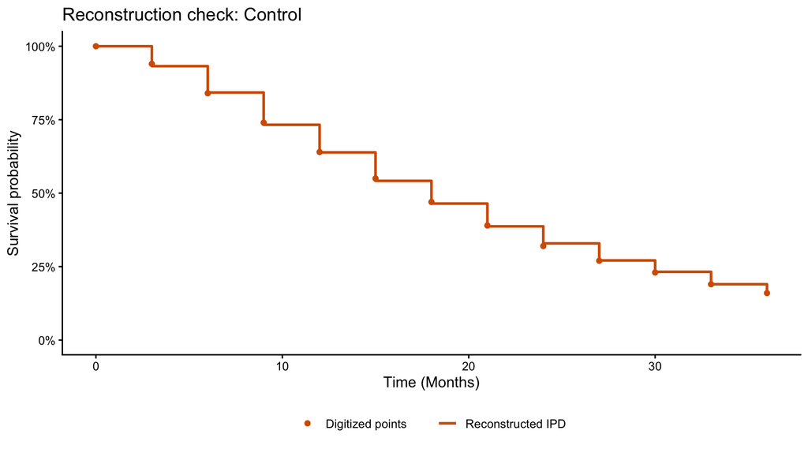

```r
plot_arm_check(risk_arm1_result, risk_arm1_label, arm_colours[1])
```

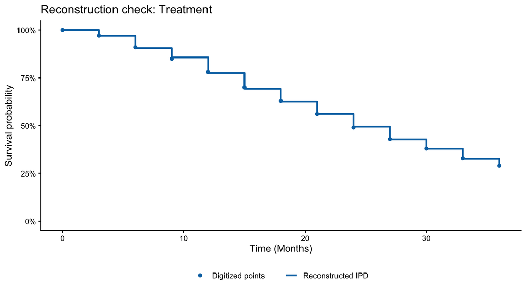

```r
plot_arm_check(risk_arm2_result, risk_arm2_label, arm_colours[2])
```

#### 3.0.17 Analyze and plot the two arms

```r
risk_km_fit <- survival::survfit(
  survival::Surv(time, status) ~ arm,
  data = combined_ipd_with_risk
)

risk_logrank <- survival::survdiff(
  survival::Surv(time, status) ~ arm,
  data = combined_ipd_with_risk
)
risk_logrank_p <- stats::pchisq(
  risk_logrank$chisq,
  df = length(risk_logrank$n) - 1L,
  lower.tail = FALSE
)

risk_cox <- survival::coxph(
  survival::Surv(time, status) ~ arm,
  data = combined_ipd_with_risk
)
risk_cox_result <- broom::tidy(
  risk_cox,
  exponentiate = TRUE,
  conf.int = TRUE
)

risk_hr <- risk_cox_result$estimate[1]
risk_hr_low <- risk_cox_result$conf.low[1]
risk_hr_high <- risk_cox_result$conf.high[1]
risk_hr_p <- risk_cox_result$p.value[1]

risk_medians <- survminer::surv_median(risk_km_fit) |>
  dplyr::transmute(
    arm = sub("^arm=", "", strata),
    median_os = median
  )

risk_arm_summary <- combined_ipd_with_risk |>
  dplyr::group_by(arm) |>
  dplyr::summarise(
    participants = dplyr::n(),
    deaths = sum(status),
    event_rate = 100 * mean(status),
    .groups = "drop"
  ) |>
  dplyr::mutate(arm = as.character(arm)) |>
  dplyr::left_join(risk_medians, by = "arm") |>
  dplyr::mutate(
    median_display = ifelse(
      is.na(median_os), "NR", sprintf("%.2f", median_os)
    ),
    event_rate_display = sprintf("%.2f%%", event_rate)
  )

risk_arm_summary |>
  dplyr::select(
    arm,
    participants,
    deaths,
    median_os = median_display,
    mortality_event_rate = event_rate_display
  )
```

```
# A tibble: 2 x 5
  arm       participants deaths median_os mortality_event_rate
  <chr>            <int>  <int> <chr>     <chr>
1 Control             62     44 18.00     70.97%
2 Treatment           68     43 24.00     63.24%
```

The final Scenario 2 figure includes two panels beneath the KM curves: the number at risk and the cumulative number censored for each reconstructed arm at every displayed time point.

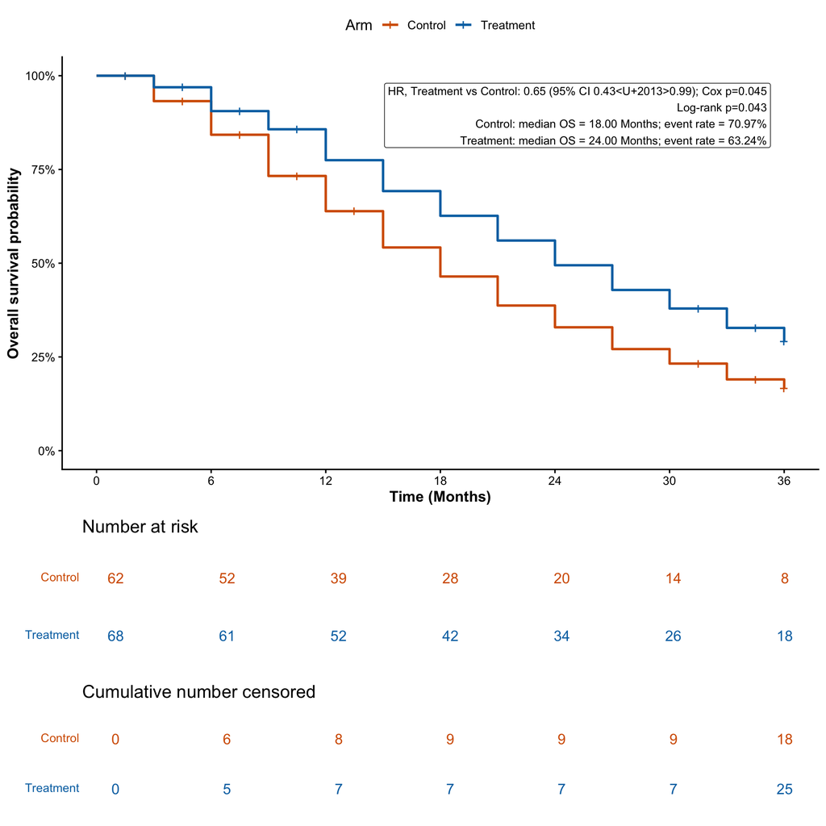

```r
risk_annotation <- paste(
  sprintf(
    "HR, %s vs %s: %.2f (95%% CI %.2f–%.2f); Cox p%s",
    risk_arm2_label,
    risk_arm1_label,
    risk_hr,
    risk_hr_low,
    risk_hr_high,
    ifelse(
      risk_hr_p < 0.001,
      "<0.001",
      paste0("=", sprintf("%.3f", risk_hr_p))
    )
  ),
  paste0(
    "Log-rank p",
    ifelse(
      risk_logrank_p < 0.001,
      "<0.001",
      paste0("=", sprintf("%.3f", risk_logrank_p))
    )
  ),
  paste0(
    risk_arm_summary$arm,
    ": median OS = ", risk_arm_summary$median_display, " ", time_unit,
    "; event rate = ", risk_arm_summary$event_rate_display,
    collapse = "\n"
  ),
  sep = "\n"
)

risk_final_plot <- survminer::ggsurvplot(
  risk_km_fit,
  data = combined_ipd_with_risk,
  risk.table = TRUE,
  risk.table.col = "strata",
  risk.table.height = 0.20,
  cumcensor = TRUE,
  cumcensor.col = "strata",
  cumcensor.height = 0.18,
  cumcensor.title = "Cumulative number censored",
  conf.int = FALSE,
  palette = arm_colours,
  legend.title = "Arm",
  legend.labs = c(risk_arm1_label, risk_arm2_label),
  xlab = paste0("Time (", time_unit, ")"),
  ylab = "Overall survival probability",
  xlim = c(0, x_axis_max),
  break.time.by = x_axis_break_by,
  surv.scale = "percent",
  ggtheme = ggplot2::theme_classic(base_size = 13),
  tables.theme = survminer::theme_cleantable(base_size = 11)
)

risk_final_plot$plot <- risk_final_plot$plot +
  ggplot2::annotate(
    "label",
    x = 0.98 * x_axis_max,
    y = 0.98,
    label = risk_annotation,
    hjust = 1,
    vjust = 1,
    size = 3.5,
    linewidth = 0.25,
    fill = scales::alpha("white", 0.88)
  ) +
  ggplot2::theme(
    legend.position = "top",
    axis.title = ggplot2::element_text(face = "bold")
  )

print(risk_final_plot)
```

##### 3.0.17.1 Sanity checks against the reported results

The same acceptance rules are applied after the numbers-at-risk reconstruction: no more than 0.20 months for either median OS and no more than 0.10 for the absolute natural-log HR ratio.

```r
scenario2_medians <- stats::setNames(
  risk_arm_summary$median_os,
  risk_arm_summary$arm
)

scenario2_sanity_checks <- run_reconstruction_sanity_checks(
  reconstructed_hr = risk_hr,
  reported_hr = risk_reported_hr_arm2_vs_arm1,
  reconstructed_medians = c(
    scenario2_medians[[risk_arm1_label]],
    scenario2_medians[[risk_arm2_label]]
  ),
  reported_medians = c(
    risk_reported_median_os_arm1,
    risk_reported_median_os_arm2
  ),
  arm_labels = c(risk_arm1_label, risk_arm2_label)
)
```

```
OVERALL RESULT: PASS - all median OS and HR sanity checks passed.
```

```r
display_sanity_check_table(
  scenario2_sanity_checks,
  "Scenario 2 reconstruction sanity checks"
)
```

**Scenario 2 reconstruction sanity checks - Overall result: PASS**

| **Characteristic** | **Median OS: Control**<sup>1</sup> | **Median OS: Treatment**<sup>1</sup> | **HR: Treatment vs Control** |
| --- | --- | --- | --- |
| Reported | 18.00 | 24.00 | 0.65 |
| Reconstructed | 18.00 | 24.00 | 0.65 |
| Absolute difference / log ratio | 0.000 | 0.000 | 0.001 |
| Acceptance limit (<=) | 0.20 | 0.20 | 0.10 |
| Result | PASS | PASS | PASS |

<sup>1</sup> Cross-check and confirm that the original and reconstructed median time to survival have been reported in the same unit of months.

## 4 Shared troubleshooting guide

### 4.1 The reconstructed curve does not agree with the reference curve

Work through these checks in order and change only one item at a time.

1. **Recheck digitization.** Zoom into the KM line, remove points captured from confidence bands, censor marks, grid lines, or another treatment arm, and ensure sufficient points were collected immediately before and after each visible step.
2. **Recalibrate both axes.** In WebPlotDigitizer, reposition `X1`, `X2`, `Y1`, and `Y2` on precisely known tick marks. Keep the calibration points far apart. Confirm that the correct linear, logarithmic, date, percentage, or fraction scale was chosen.
3. **Adjust the calibration bounds.** Small changes in the assumed `X1`, `X2`, `Y1`, and `Y2` values can expose a poorly aligned crop or an axis origin that was estimated rather than observed. Do not tune these values merely to force agreement; document any defensible correction.
4. **Check delta-X and delta-Y behavior.** Compare a few digitized points with tick marks whose coordinates are known. A discrepancy that grows across the x-axis suggests an x calibration or crop problem; a discrepancy that grows vertically suggests a y calibration or percentage-scale problem.
5. **Confirm survival units.** The algorithm requires survival probabilities from 0 to 1. Divide values from 0 to 100 by 100. Do not inadvertently digitize cumulative mortality or failure probability without converting it to survival.
6. **Confirm time units and rescaling.** Check months versus years and verify whether the digitized x-axis is already in real time. Apply `time_max` only to normalized 0-to-1 coordinates.
7. **Inspect time ordering and duplicate points.** Time must increase and survival must not increase. Examine the cleaned curve for duplicated times, upward jumps, missing starting values, and points outside the plot range.
8. **Verify the risk table transcription.** Check that risk counts belong to the correct arm and line up with the correct time ticks. Counts must be non-increasing and cannot exceed the baseline sample size.
9. **Check the final risk time.** It must occur before the last digitized curve point so the algorithm has a final interval over which it can estimate censoring.
10. **Compare in stages.** First compare digitized points with the cleaned curve; then compare the reconstructed curve with the cleaned curve; finally compare published and reconstructed risk counts. This identifies where discordance begins.
11. **Increase digitization density selectively.** Add points near steep drops, curve crossings, long flat regions followed by drops, and the tail where few participants remain. More points on perfectly flat segments usually add little information.
12. **Review rounding and sparse tails.** Integer rounding matters when risk sets are small. Tail discrepancies may be unavoidable and should be reported rather than hidden.
13. **Check reported summary statistics.** Compare reconstructed medians, landmark survival, total events, and HRs with published values. Large disagreements may identify an incorrect arm, time scale, endpoint definition, or risk table.
14. **Assess proportional hazards.** A visually good reconstruction does not guarantee that one Cox HR is an adequate treatment summary. Inspect curve crossings and consider time-varying effects or restricted mean survival time when appropriate.

**Important**

Never alter calibration or inputs solely to reproduce a desired HR. Every correction should be traceable to the source figure, its axes, or its accompanying table.

### 4.2 Common error messages

| Message or symptom | Likely cause | What to do |
| --- | --- | --- |
| “Digitized file not found” | Placeholder path or incorrect working directory | Use an absolute path or confirm the project-relative path with `file.exists()` |
| “At least two valid points” | Header interpreted as data, nonnumeric columns, or an empty export | Open the CSV and confirm the first two columns are numeric time and survival |
| Risk times must be increasing | Duplicated or out-of-order risk-table times | Correct the transcription and keep time 0 as the first value |
| Last risk time must be earlier than last digitized time | The digitized curve ends too early | Digitize beyond the final reported risk time or omit that final risk-table column with justification |
| Published risk count was not attainable | Curve, risk table, and censoring allocation are internally inconsistent | Recheck digitization and calibration; inspect that interval closely |
| Events plus censoring exceed baseline N | Invalid counts or a failure to converge | Recheck baseline N and risk counts; inspect interval diagnostics before analysis |
| Median is `NR` | Survival never fell to 50% | Report “not reached”; do not replace it with the last follow-up time |

## 5 Running the code

The `.qmd` source contains executable R chunks. Open it in RStudio or Positron and use the **Run** button on each chunk to watch the objects, tables, and plots appear in sequence. The rendered HTML shows the results generated from the dummy data and provides copy buttons, but a self-contained static HTML file opened with `file://` cannot start an R session.

For true execution inside a hosted webpage, use one of these deployment approaches:

- **Shiny for Quarto:** full R execution and file upload, but it requires a Shiny-capable server.
- **Shinylive/webR:** R runs in the browser without a server, but package availability, download size, browser memory, and loading time must be tested carefully for `survival` and plotting dependencies.

The static tutorial is therefore the dependable teaching version; a hosted interactive application should be treated as a separate deployment target.

## 6 Learning resources

- [Open WebPlotDigitizer](https://automeris.io)
- [Video tutorial 1 supplied with this guide](https://youtu.be/j2BxnTNz-Gw?is=rBCta2fk8rl0H9j-)
- [Video tutorial 2 supplied with this guide](https://youtu.be/eHuQlIDRXxs?is=2vs_JS1NogGEq_Hp)
- [Guyot et al.: reconstructing IPD from published KM curves](https://pmc.ncbi.nlm.nih.gov/articles/PMC3313891/)